# Projekt CV

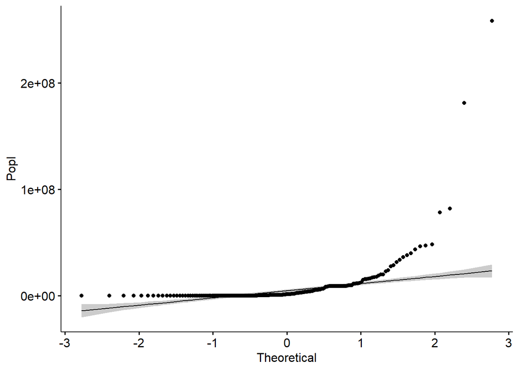

```r
ggqqplot(Dane$Popl, ylab = "Popl")
```

Przedstawienie na wykresie rozkładu normlanego modeli “Model” oraz “Model_no_outliers”. Kod pokazuje wizualizację danych i sprawdza, czy reszty regresji są zgodne z rozkładem normalnym. * “par(mfrow=c(1,1))” - oznacza, że na każdej stronie wyników będzie tylko jeden wykres. * “qqnorm(Model$res,ylab="Residuals")" - rysuje wykres typu Q-Q plot dla reszt regresji Model, z opisem osi y jako "Residuals". * "qqline(Model$res, col=”blue”)” - dodaje linię do wykresu typu Q-Q plot, która pokazuje, jak dane powinny odpowiadać rozkładowi normalnemu. Kolor linii to niebieski.

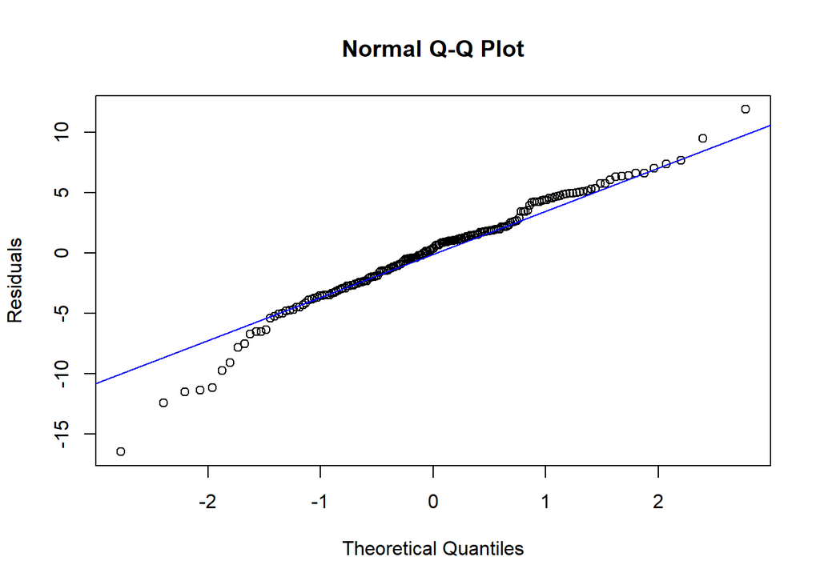

```r
par(mfrow=c(1,1))
qqnorm(Model$res,ylab="Residuals")
qqline(Model$res, col="blue")
```

Przedstawienie na wykresie rozkładu normlanego modeli “Model” oraz “Model_no_outliers” z użyciem funkcji “rstudent”. * “qqnorm(Model_no_outliers$res,ylab="Residuals")" - rysuje wykres typu Q-Q plot dla reszt regresji Model_no_outliers, z opisem osi y jako "Residuals". * "qqline(Model_no_outliers$res, col=”blue”)” - dodaje linię do wykresu typu Q-Q plot, która pokazuje, jak dane powinny odpowiadać rozkładowi normalnemu. Kolor linii to niebieski. * “qqnorm(rstudent(Model),ylab=”Studentized residuals”)” - rysuje wykres typu Q-Q plot dla studentyzowanych reszt regresji Model, z opisem osi y jako “Studentized residuals”. * “abline(0,1)” - dodaje prostą do wykresu typu Q-Q plot, która pokazuje, jak dane powinny odpowiadać rozkładowi normalnemu. * “qqnorm(rstudent(Model_no_outliers),ylab=”Studentized residuals”)” - rysuje wykres typu Q-Q plot dla studentyzowanych reszt regresji Model_no_outliers, z opisem osi y jako “Studentized residuals”. * “abline(0,1)” - dodaje prostą do wykresu typu Q-Q plot, która pokazuje, jak dane powinny odpowiadać rozkładowi normalnemu.

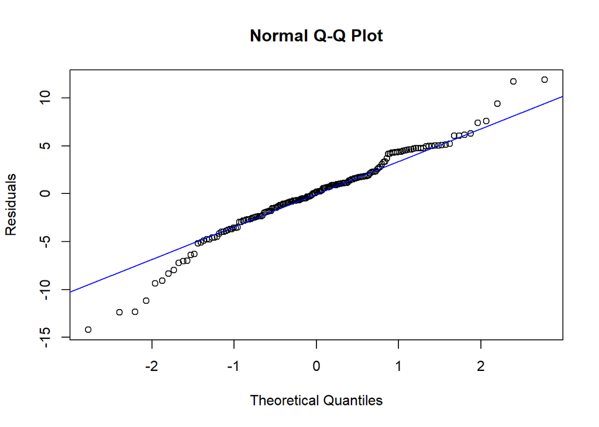

```r
par(mfrow=c(1,1))
qqnorm(Model_no_outliers$res,ylab="Residuals")
qqline(Model_no_outliers$res, col="blue")
```

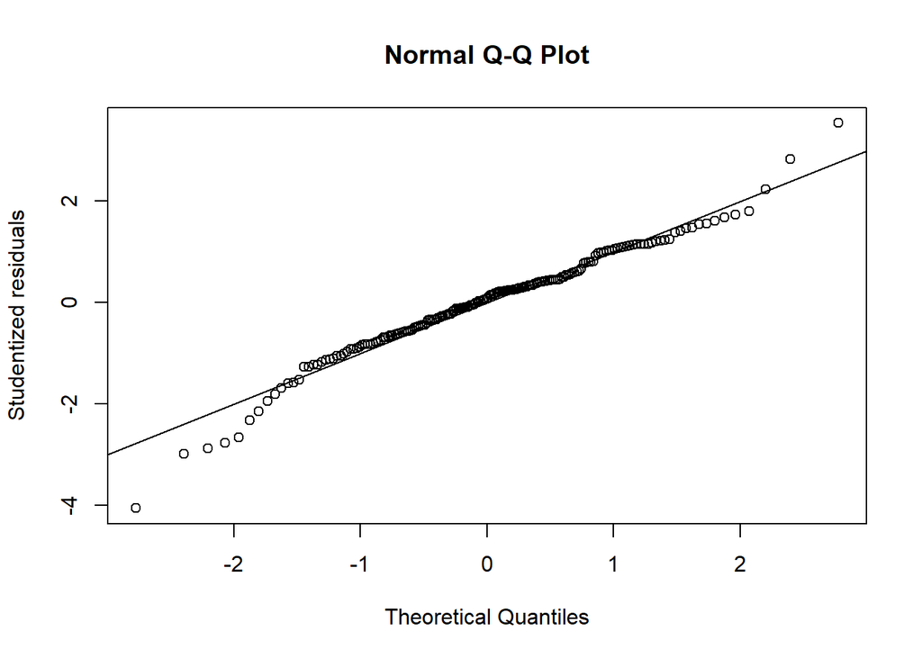

```r
qqnorm(rstudent(Model),ylab="Studentized residuals")
abline(0,1)
```

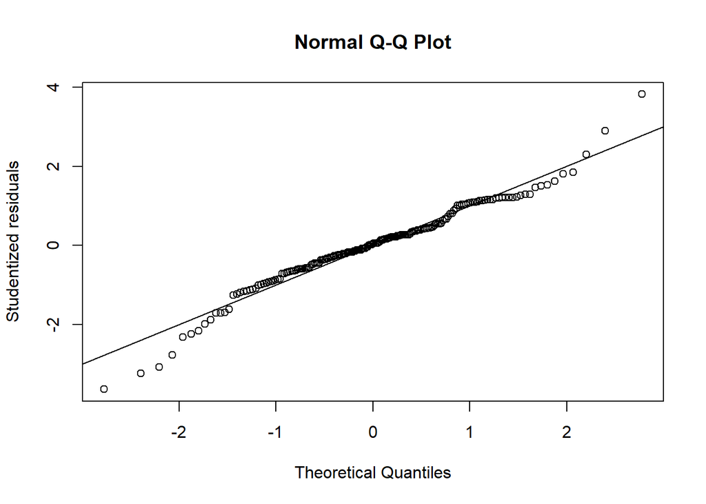

```r
qqnorm(rstudent(Model_no_outliers),ylab="Studentized residuals")
abline(0,1)
```

W celu sprawdzenia rozkładu normlanego użyje testu Shapiro-Wilka. P-value w teście Shapiro-Wilka jest miarą siły dowodu przeciwko hipotezie, że dane pochodzą z rozkładu normalnego. Im mniejsze p-value, tym mocniejszy jest dowód przeciwko hipotezie normalności. Jeśli p-value jest mniejsze niż poziom istotności (np. 0,05), to odrzucamy hipotezę normalności i stwierdzamy, że dane nie pochodzą z rozkładu normalnego. W przeciwnym razie przyjmujemy hipotezę normalności. Za pomocą “shapiro.test” mogłem uzyskać następująće wyniki * Dla modelu “Model” wynik wyszedł W = 0.97386, p-value = 0.001701. Poniżej 0,05 p-value rozkład nie jest normalny. * Dla modelu “Model2” wynik wyszedł W = 0.97416, p-value = 0.001852. Poniżej 0,05 p-value rozkład nie jest normalny. * Dla modelu “Model3” wynik wyszedł W = 0.97468, p-value = 0.002148. Poniżej 0,05 p-value rozkład nie jest normalny. * Dla modelu “Model4” wynik wyszedł W = 0.97386, p-value = 0.001701. Poniżej 0,05 p-value rozkład nie jest normalny. * Dla modelu “Model5” wynik wyszedł W = 0.97026, p-value = 0.0006324. Poniżej 0,05 p-value rozkład nie jest normalny. * Dla modelu “Model_no_outlires” wynik wyszedł W = 0.97233, p-value = 0.001155. Poniżej 0,05 p-value rozkład nie jest normalny. Wszystkie modele uzyskały wynik p-value poniżej 0,05, co czynni je niepochodzących z rozkładu normlanego. Jednocześnie wyniki są bardzo zbliżone. Nie zmieniam modelu, a modelem jest model “Model4”.

```r
shapiro.test(Model$res)
```

```
##
##  Shapiro-Wilk normality test
##
## data:  Model$res
## W = 0.97386, p-value = 0.001701
```

```r
shapiro.test(Model2$res)
```

```
##
##  Shapiro-Wilk normality test
##
## data:  Model2$res
## W = 0.97416, p-value = 0.001852
```

```r
shapiro.test(Model3$res)
```

```
##
##  Shapiro-Wilk normality test
##
## data:  Model3$res
## W = 0.97468, p-value = 0.002148
```

```r
shapiro.test(Model4$res)
```

```
##
##  Shapiro-Wilk normality test
##
## data:  Model4$res
## W = 0.97386, p-value = 0.001701
```

```r
shapiro.test(Model5$res)
```

```
##
##  Shapiro-Wilk normality test
##
## data:  Model5$res
## W = 0.97026, p-value = 0.0006324
```

```r
shapiro.test(Model_no_outliers$res)
```

```
##
##  Shapiro-Wilk normality test
##
## data:  Model_no_outliers$res
## W = 0.97233, p-value = 0.001155
```

Test niezależności Kod ładuje bibliotekę “randtests” i wywołuje funkcję “runs.test” na zmiennej “Model$res" oraz Model_no_outliers$res”. Funkcja “runs.test” jest jednym z testów dla oceny losowości w sekwencji wartości. Test jest wykonywany na “residulas” z modelu statystycznego. Wynik testu przedstawia czy wartości “residuals” są losowe, czy są skorelowane. Jeśli wartości danych byłyby losowe, można oczekiwać, że liczba ciągów wzrostów i spadków wartości byłaby podobna. Jeśli natomiast wartości danych byłyby skorelowane, można oczekiwać, że będzie więcej ciągów wzrostów niż spadków, lub na odwrót. W obu przypadkach moje model są powyżej 0.05 p-value, oznacza to, że nie odrzucaja hipotezę zerową i wartości są losowe.

```r
library(randtests)
```

```r
runs.test(Model$res)
```

```
##
##  Runs Test
##
## data:  Model$res
## statistic = 0.14866, runs = 93, n1 = 91, n2 = 91, n = 182, p-value =
## 0.8818
## alternative hypothesis: nonrandomness
```

```r
runs.test(Model_no_outliers$res)
```

```
##
##  Runs Test
##
## data:  Model_no_outliers$res
## statistic = 0, runs = 91, n1 = 90, n2 = 90, n = 180, p-value = 1
## alternative hypothesis: nonrandomness
```

Kod oznacza wykonanie analiz regresji dla zmiennych wyjaśniających w zbiorze danych Dane. W pierwszej linijce tworzy się macierz explanatory z wykluczeniem pierwszej kolumny Dane. Następnie tworzy się model regresji dla pierwszej kolumny explanatory jako zmiennej zależnej i pozostałych kolumn explanatory jako zmiennych niezależnych. Podsumowanie modelu jest wyświetlane za pomocą funkcji summary(). Wartość współczynnika determinacji dla tego modelu jest pobierana z jego podsumowania.

```r
explanatory<-as.matrix(Dane[,-1])
```

```r
summary(lm(explanatory[,1]~explanatory[,-1]))
```

```
##
## Call:
## lm(formula = explanatory[, 1] ~ explanatory[, -1])
##
## Residuals:
##      Min       1Q   Median       3Q      Max
## -232.418  -50.191    0.923   43.754  246.229
##
## Coefficients:
##                             Estimate Std. Error t value Pr(>|t|)
## (Intercept)                2.636e+02  2.733e+01   9.647  < 2e-16 ***
## explanatory[, -1]Infant_D -1.762e+00  8.844e-01  -1.992  0.04791 *
## explanatory[, -1]H_B       1.131e+00  6.450e-01   1.753  0.08145 .
## explanatory[, -1]Measles  -7.701e-04  1.511e-03  -0.510  0.61098
## explanatory[, -1]Under_D   1.557e+00  6.518e-01   2.389  0.01799 *
## explanatory[, -1]Polio    -1.039e+00  3.547e-01  -2.930  0.00385 **
## explanatory[, -1]Dipht    -1.291e+00  7.421e-01  -1.739  0.08384 .
## explanatory[, -1]GDP      -1.698e-03  6.102e-04  -2.783  0.00600 **
## explanatory[, -1]Popl     -4.823e-07  2.791e-07  -1.728  0.08575 .
## explanatory[, -1]Income    3.595e-01  6.796e-01   0.529  0.59749
## ---
## Signif. codes:  0 '***' 0.001 '**' 0.01 '*' 0.05 '.' 0.1 ' ' 1
##
## Residual standard error: 83.72 on 172 degrees of freedom
## Multiple R-squared:  0.2791, Adjusted R-squared:  0.2414
## F-statistic:   7.4 on 9 and 172 DF,  p-value: 4.237e-09
```

```r
summary(lm(explanatory[,1]~explanatory[,-1]))$r.squared
```

```
## [1] 0.2791155
```

W tej części kodu zaimportowana jest biblioteka “car” i wykonane jest obliczenie Variance Inflation Factor (VIF) dla modelu “Model” automatycznie. VIF jest miarą multicollinearity (wzajemnej korelacji) pomiędzy zmiennymi niezależnymi w modelu regresji. Wartość VIF powyżej 10 sugeruje występowanie wzajemnej korelacji i konieczność usunięcia jednej z kolumn explanatory. W moim modelu takimi wartościami są “Infant_D” oraz “Under_D”.

```r
library(car)
vif(Model)
```

```
##   Adult_M  Infant_D   Under_D     Polio     Dipht       GDP      Popl
##  1.359195 95.660047 99.401120  2.015937  1.889497  1.147135  1.347827
```

Za pomocą “Model”, mogłem dostać współczynniki dla wszystkich zmiennych.

```r
Model$coefficients
```

```
##   (Intercept)       Adult_M      Infant_D       Under_D         Polio
##  6.935148e+01 -4.730148e-02  9.560769e-02 -8.205823e-02  5.021274e-02
##         Dipht           GDP          Popl
##  5.425434e-02  1.211242e-04  2.472045e-08
```

```r
beta_0<-Model$coefficients['(Intercept)']
beta_0
```

```
## (Intercept)
##    69.35148
```

```r
beta_adultm<-Model$coefficients['Adult_M']
beta_adultm
```

```
##     Adult_M
## -0.04730148
```

```r
beta_infantd<-Model$coefficients['Infant_D']
beta_infantd
```

```
##   Infant_D
## 0.09560769
```

```r
beta_underd<-Model$coefficients['Under_D']
beta_underd
```

```
##     Under_D
## -0.08205823
```

```r
beta_polio<-Model$coefficients['Polio']
beta_polio
```

```
##      Polio
## 0.05021274
```

```r
beta_dipht<-Model$coefficients['Dipht']
beta_dipht
```

```
##      Dipht
## 0.05425434
```

```r
beta_gdp<-Model$coefficients['GDP']
beta_gdp
```

```
##          GDP
## 0.0001211242
```

```r
beta_popl<-Model$coefficients['Popl']
beta_popl
```

```
##         Popl
## 2.472045e-08
```

Dzięki stworzeniu bet, mogę dokonać predykcji. Stworzyłem 3 różne predykcje z różnymi liczbami. Przykładowo w “forecast” zakładając, że: * “Adult Mortality” jest na poziomie 100 * “Infant deaths” jest na poziomie 56 * “Under-five deaths” jest na poziomie 80 * “Polio” jest na poziomie 70 * “Diphtheria” jest na poziomie 80 * “GDP” jest na poziomie 300 * “Population” jest na poziomie 10000000 Wynik oczekiwanej długości życia według modelu wynosi 71.54948.

```r
(forecast<-beta_0+beta_adultm*100+beta_infantd*56+beta_underd*80+beta_polio*70+beta_dipht*80+beta_gdp*300+beta_popl*10000000)
```

```
## (Intercept)
##    71.54948
```

```r
(forecast2<-beta_0+beta_adultm*500+beta_infantd*86+beta_underd*90+beta_polio*73+beta_dipht*94+beta_gdp*456+beta_popl*9080000)
```

```
## (Intercept)
##    55.58289
```

```r
(forecast3<-beta_0+beta_adultm*60+beta_infantd*47+beta_underd*52+beta_polio*64+beta_dipht*45+beta_gdp*291+beta_popl*13768000)
```

```
## (Intercept)
##    72.77058
```

W już końcowym etapie projektu dostrzegłem możliwość innego wprowadzenia danych. Użyłem sposobu zmiany danych w RStudio. Musiałem użyć nowego pakietu “tidyverse”, aby odczytało moje dane w formacie “csv”. Tak dostałem dane z prawidłowym odczytem kolumn, które w excelu nie działały, dzięki temu dostałem dostęp do danych, które bardzo mnie ciekawiły i chciałem użyć wcześniej. Postanowiłem nie usuwać poprzedniej pracy w celu sprawozdania pracy i dostania możliwych ciekawych wyników. Instalacja pakietu i uruchomienie go, aby użyć funkcji “read_csv”

```r
library(tidyverse)
```

Stworzenie nowego wektora z nową bazą danych, o nazwie “Dane_nowe”

```r
Dane_nowe <-  read_csv("C:/Users/Kacper/Desktop/Projekt Regression/Dane z 2015.csv")
View(Dane_nowe)
names(Dane_nowe)
```

```
##  [1] "Country"                         "Year"
##  [3] "Status"                          "Life expectancy"
##  [5] "Adult Mortality"                 "infant deaths"
##  [7] "Alcohol"                         "percentage expenditure"
##  [9] "Hepatitis B"                     "Measles"
## [11] "BMI"                             "under-five deaths"
## [13] "Polio"                           "Total expenditure"
## [15] "Diphtheria"                      "HIV/AIDS"
## [17] "GDP"                             "Population"
## [19] "thinness  1-19 years"            "thinness 5-9 years"
## [21] "Income composition of resources" "Schooling"
```

Działania kodu: Ładuje bibliotekę “dplyr”, która zapewnia zestaw narzędzi do pracy z ramkami danych w R. Używa biblioteki “dplyr” do modyfikowania ramki danych “Dane_nowe”. Funkcja “select” jest używana do wybierania kolumn z ramki danych, a argument “-c(Country, Year, Status, Alcohol, percentage expenditure, Total expenditure)” jest używany, aby wykluczyć określone kolumny z ramki danych. Rezultat jest przypisywany z powrotem do “Dane_nowe” za pomocą operatora rury “%>%”. Wywołuje funkcję “View”, aby wyświetlić zawartość zmodyfikowanej ramki danych “Dane_nowe” w formacie tabeli. Wywołuje funkcję “names”, aby wyświetlić nazwy kolumn w zmodyfikowanej ramce danych “Dane_nowe”.

```r
library("dplyr")
Dane_nowe <- Dane_nowe %>% select(-c(Country, Year, Status, Alcohol, `percentage expenditure`, `Total expenditure`))
View(Dane_nowe)
names(Dane_nowe)
```

```
##  [1] "Life expectancy"                 "Adult Mortality"
##  [3] "infant deaths"                   "Hepatitis B"
##  [5] "Measles"                         "BMI"
##  [7] "under-five deaths"               "Polio"
##  [9] "Diphtheria"                      "HIV/AIDS"
## [11] "GDP"                             "Population"
## [13] "thinness  1-19 years"            "thinness 5-9 years"
## [15] "Income composition of resources" "Schooling"
```

Przydzielanie nowych nazw kolumną.

```r
colnames(Dane_nowe)<-c("Life","Adult_M","Infant_D","H_B","Measles","BMI", "Under_D","Polio","Dipht","H/A", "GDP","Popl", "t_1-19", "t_5-9", "Income", "Schooling")
```

Działania kodu: Tworzy nową kolumnę w ramce danych “Dane_nowe” o nazwie “H_B”. Używa funkcji “ifelse” do wypełnienia brakujących wartości (reprezentowanych przez “NA”) w kolumnie “H_B”. Jeśli wartość w danej komórce kolumny “H_B” jest “NA”, oblicza się średnią wszystkich niebrakujących wartości w kolumnie “H_B” za pomocą funkcji “mean” z argumentem “na.rm = TRUE”, który usuwa brakujące wartości z obliczeń. Jeśli wartość w danej komórce kolumny “H_B” nie jest “NA”, wartość pozostaje niezmieniona. Rezultat jest przypisywany z powrotem do kolumny “Dane_nowe$H_B”.

```r
Dane_nowe$H_B = ifelse(is.na(Dane_nowe$H_B),
                       ave(Dane_nowe$H_B, FUN = function(x) mean(x, na.rm = TRUE)),
                       Dane_nowe$H_B)
```

Działania te są wykonywane na reszcie kolumn z brakującymi danymi.

```r
Dane_nowe$BMI = ifelse(is.na(Dane_nowe$BMI ),
                       ave(Dane_nowe$BMI , FUN = function(x) mean(x, na.rm = TRUE)),
                       Dane_nowe$BMI )
Dane_nowe$GDP = ifelse(is.na(Dane_nowe$GDP ),
                       ave(Dane_nowe$GDP  , FUN = function(x) mean(x, na.rm = TRUE)),
                       Dane_nowe$GDP  )
Dane_nowe$Popl = ifelse(is.na(Dane_nowe$Popl  ),
                       ave(Dane_nowe$Popl   , FUN = function(x) mean(x, na.rm = TRUE)),
                       Dane_nowe$Popl   )
Dane_nowe$`t_1-19`  = ifelse(is.na(Dane_nowe$`t_1-19`   ),
                        ave(Dane_nowe$`t_1-19`   , FUN = function(x) mean(x, na.rm = TRUE)),
                        Dane_nowe$`t_1-19`   )
Dane_nowe$`t_5-9` = ifelse(is.na(Dane_nowe$`t_5-9`   ),
                        ave(Dane_nowe$`t_5-9`    , FUN = function(x) mean(x, na.rm = TRUE)),
                        Dane_nowe$`t_5-9`    )
Dane_nowe$Income = ifelse(is.na(Dane_nowe$Income    ),
                           ave(Dane_nowe$Income    , FUN = function(x) mean(x, na.rm = TRUE)),
                           Dane_nowe$Income    )
Dane_nowe$Schooling = ifelse(is.na(Dane_nowe$Schooling   ),
                          ave(Dane_nowe$Schooling    , FUN = function(x) mean(x, na.rm = TRUE)),
                          Dane_nowe$Schooling    )
```

```r
matrix_nowy <- as.matrix(Dane_nowe[,-1])

matrix_eigen_nowy <- eigen(t(matrix_nowy) %*% matrix_nowy)
matrix_eigen_nowy$val
```

```
##  [1] 1.406867e+17 2.824722e+10 1.119625e+10 6.451890e+06 1.254072e+06
##  [6] 7.715249e+05 6.910248e+04 4.464387e+04 7.941367e+03 5.960368e+03
## [11] 3.273808e+03 1.132892e+03 1.812325e+02 7.168875e+01 9.788778e-01
```

```r
sqrt(matrix_eigen_nowy$val[1]/matrix_eigen_nowy$val)
```

```
##  [1] 1.000000e+00 2.231714e+03 3.544788e+03 1.476668e+05 3.349387e+05
##  [6] 4.270232e+05 1.426854e+06 1.775193e+06 4.208999e+06 4.858363e+06
## [11] 6.555410e+06 1.114377e+07 2.786175e+07 4.429972e+07 3.791074e+08
```

Kod tworzy nowy model regresji liniowej “Model_nowy” z zmienną objaśnianą “Life” i kilkoma zmiennymi objaśniającymi: “Adult_M”, “Infant_D”, “H_B”, “Measles”, “BMI”, “Under_D”, “Polio”, “Dipht”, “H/A”, “GDP”, “Popl”, “t_1-19”, “t_5-9”, “Income”, “Schooling”. Dane są wczytywane z data frame’u “Dane_nowe”. W końcowym kroku jest wyświetlany podsumowanie modelu regresji liniowej “Model_nowy”.

```r
Model_nowy <- lm(Life~Adult_M+Infant_D+H_B+Measles+BMI+Under_D+Polio+Dipht+`H/A`+GDP+Popl+`t_1-19`+`t_5-9`+Income+Schooling,data=Dane_nowe)
summary(Model_nowy)
```

```
##
## Call:
## lm(formula = Life ~ Adult_M + Infant_D + H_B + Measles + BMI +
##     Under_D + Polio + Dipht + `H/A` + GDP + Popl + `t_1-19` +
##     `t_5-9` + Income + Schooling, data = Dane_nowe)
##
## Residuals:
##     Min      1Q  Median      3Q     Max
## -9.0242 -1.4732  0.0279  1.5076  7.6316
##
## Coefficients:
##               Estimate Std. Error t value Pr(>|t|)
## (Intercept)  5.325e+01  2.112e+00  25.214  < 2e-16 ***
## Adult_M     -2.512e-02  3.473e-03  -7.233 1.65e-11 ***
## Infant_D     9.068e-02  3.411e-02   2.659  0.00862 **
## H_B          2.476e-02  2.359e-02   1.050  0.29526
## Measles     -4.671e-05  5.591e-05  -0.835  0.40471
## BMI         -2.990e-03  1.395e-02  -0.214  0.83062
## Under_D     -6.832e-02  2.482e-02  -2.753  0.00656 **
## Polio        1.469e-02  1.332e-02   1.103  0.27170
## Dipht        1.143e-02  2.743e-02   0.417  0.67733
## `H/A`       -4.438e-01  2.287e-01  -1.940  0.05402 .
## GDP          5.588e-06  2.414e-05   0.231  0.81721
## Popl         4.571e-09  1.029e-08   0.444  0.65730
## `t_1-19`    -1.883e-01  2.496e-01  -0.754  0.45171
## `t_5-9`     -2.071e-02  2.462e-01  -0.084  0.93307
## Income       2.713e+01  4.619e+00   5.872 2.28e-08 ***
## Schooling    4.810e-02  2.037e-01   0.236  0.81364
## ---
## Signif. codes:  0 '***' 0.001 '**' 0.01 '*' 0.05 '.' 0.1 ' ' 1
##
## Residual standard error: 2.97 on 166 degrees of freedom
## Multiple R-squared:  0.8746, Adjusted R-squared:  0.8633
## F-statistic: 77.19 on 15 and 166 DF,  p-value: < 2.2e-16
```

Użycie metody “backward”, aby ustalić najlepszy model.

```r
Model_nowy_backward<-step(lm(Life~Adult_M+Infant_D+H_B+Measles+BMI+Under_D+Polio+Dipht+`H/A`+GDP+Popl+`t_1-19`+`t_5-9`+Income+Schooling,data=Dane_nowe),direction="backward")
```

```
## Start:  AIC=411.43
## Life ~ Adult_M + Infant_D + H_B + Measles + BMI + Under_D + Polio +
##     Dipht + `H/A` + GDP + Popl + `t_1-19` + `t_5-9` + Income +
##     Schooling
##
##             Df Sum of Sq    RSS    AIC
## - `t_5-9`    1      0.06 1463.8 409.44
## - BMI        1      0.40 1464.2 409.48
## - GDP        1      0.47 1464.3 409.49
## - Schooling  1      0.49 1464.3 409.49
## - Dipht      1      1.53 1465.3 409.62
## - Popl       1      1.74 1465.5 409.65
## - `t_1-19`   1      5.02 1468.8 410.05
## - Measles    1      6.15 1469.9 410.19
## - H_B        1      9.72 1473.5 410.63
## - Polio      1     10.72 1474.5 410.76
## <none>                   1463.8 411.43
## - `H/A`      1     33.20 1497.0 413.51
## - Infant_D   1     62.32 1526.1 417.02
## - Under_D    1     66.85 1530.6 417.56
## - Income     1    304.08 1767.9 443.78
## - Adult_M    1    461.32 1925.1 459.29
##
## Step:  AIC=409.44
## Life ~ Adult_M + Infant_D + H_B + Measles + BMI + Under_D + Polio +
##     Dipht + `H/A` + GDP + Popl + `t_1-19` + Income + Schooling
##
##             Df Sum of Sq    RSS    AIC
## - BMI        1      0.36 1464.2 407.48
## - GDP        1      0.48 1464.3 407.50
## - Schooling  1      0.48 1464.3 407.50
## - Dipht      1      1.65 1465.5 407.64
## - Popl       1      1.75 1465.6 407.65
## - Measles    1      6.09 1469.9 408.19
## - H_B        1      9.72 1473.6 408.64
## - Polio      1     10.68 1474.5 408.76
## <none>                   1463.8 409.44
## - `H/A`      1     33.73 1497.6 411.58
## - `t_1-19`   1     61.02 1524.9 414.87
## - Infant_D   1     62.81 1526.7 415.08
```

[output cut: 107 more lines]

```
## - Income    1   1407.00 2881.5 518.70
##
## Step:  AIC=398.3
## Life ~ Adult_M + Infant_D + H_B + Under_D + `H/A` + `t_1-19` +
##     Income
##
##            Df Sum of Sq    RSS    AIC
## <none>                  1487.1 398.30
## - `H/A`     1     37.51 1524.6 400.84
## - `t_1-19`  1     59.79 1546.9 403.48
## - Infant_D  1     63.46 1550.5 403.91
## - Under_D   1     65.73 1552.8 404.17
## - H_B       1    134.08 1621.2 412.01
## - Adult_M   1    483.96 1971.0 447.58
## - Income    1   1514.79 3001.9 524.14
```

```r
summary(Model_nowy_backward)
```

```
##
## Call:
## lm(formula = Life ~ Adult_M + Infant_D + H_B + Under_D + `H/A` +
##     `t_1-19` + Income, data = Dane_nowe)
##
## Residuals:
##     Min      1Q  Median      3Q     Max
## -9.7571 -1.4736 -0.1144  1.6313  8.0334
##
## Coefficients:
##              Estimate Std. Error t value Pr(>|t|)
## (Intercept) 53.331379   1.970747  27.062  < 2e-16 ***
## Adult_M     -0.025318   0.003364  -7.525 2.71e-12 ***
## Infant_D     0.069914   0.025657   2.725 0.007088 **
## H_B          0.040848   0.010313   3.961 0.000109 ***
## Under_D     -0.054905   0.019797  -2.773 0.006154 **
## `H/A`       -0.458897   0.219038  -2.095 0.037614 *
## `t_1-19`    -0.192444   0.072761  -2.645 0.008919 **
## Income      29.053282   2.182283  13.313  < 2e-16 ***
## ---
## Signif. codes:  0 '***' 0.001 '**' 0.01 '*' 0.05 '.' 0.1 ' ' 1
##
## Residual standard error: 2.923 on 174 degrees of freedom
## Multiple R-squared:  0.8726, Adjusted R-squared:  0.8675
## F-statistic: 170.3 on 7 and 174 DF,  p-value: < 2.2e-16
```

Finalny wynik jest bardzo optymistyczny, ponieważ wynik R-squared wynosi 0.8726 (zmienność oczekiwanej długości życia jest wyjaśniony w 87% przez model), a “Adjusted R-squared” wynosi 0.8675.

```r
Model_nowy <- Model_nowy_backward
summary(Model_nowy)
```

```
##
## Call:
## lm(formula = Life ~ Adult_M + Infant_D + H_B + Under_D + `H/A` +
##     `t_1-19` + Income, data = Dane_nowe)
##
## Residuals:
##     Min      1Q  Median      3Q     Max
## -9.7571 -1.4736 -0.1144  1.6313  8.0334
##
## Coefficients:
##              Estimate Std. Error t value Pr(>|t|)
## (Intercept) 53.331379   1.970747  27.062  < 2e-16 ***
## Adult_M     -0.025318   0.003364  -7.525 2.71e-12 ***
## Infant_D     0.069914   0.025657   2.725 0.007088 **
## H_B          0.040848   0.010313   3.961 0.000109 ***
## Under_D     -0.054905   0.019797  -2.773 0.006154 **
## `H/A`       -0.458897   0.219038  -2.095 0.037614 *
## `t_1-19`    -0.192444   0.072761  -2.645 0.008919 **
## Income      29.053282   2.182283  13.313  < 2e-16 ***
## ---
## Signif. codes:  0 '***' 0.001 '**' 0.01 '*' 0.05 '.' 0.1 ' ' 1
##
## Residual standard error: 2.923 on 174 degrees of freedom
## Multiple R-squared:  0.8726, Adjusted R-squared:  0.8675
## F-statistic: 170.3 on 7 and 174 DF,  p-value: < 2.2e-16
```

Sprawdzenie outlierów oraz stworzenie nowego modelu z usunietymi wartościami odstającymi.

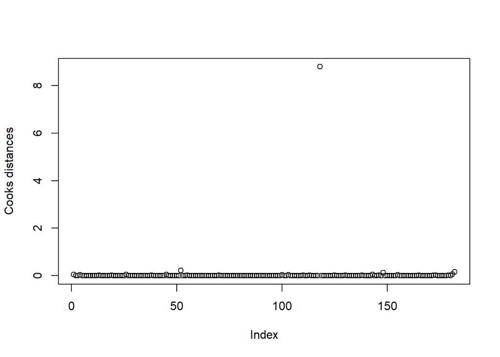

```r
cooks_dis <- cooks.distance(Model_nowy)
plot(cooks_dis,ylab="Cooks distances")
```

```r
Model_nowy_no_outliers <-lm(Life~Adult_M+Infant_D+H_B+Under_D+`H/A`+`t_1-19`+Income,data=Dane_nowe,subset=(cooks_dis<max(cooks_dis)))
```

```r
summary(Model_nowy_no_outliers)
```

```
##
## Call:
## lm(formula = Life ~ Adult_M + Infant_D + H_B + Under_D + `H/A` +
##     `t_1-19` + Income, data = Dane_nowe, subset = (cooks_dis <
##     max(cooks_dis)))
##
## Residuals:
##     Min      1Q  Median      3Q     Max
## -8.7930 -1.5945 -0.0056  1.5528  8.2047
##
## Coefficients:
##              Estimate Std. Error t value Pr(>|t|)
## (Intercept) 55.166752   1.991738  27.698  < 2e-16 ***
## Adult_M     -0.024734   0.003274  -7.554 2.33e-12 ***
## Infant_D     0.243635   0.057474   4.239 3.65e-05 ***
## H_B          0.038465   0.010047   3.829  0.00018 ***
## Under_D     -0.198851   0.047024  -4.229 3.80e-05 ***
## `H/A`       -0.485941   0.213008  -2.281  0.02375 *
## `t_1-19`    -0.185696   0.070736  -2.625  0.00943 **
## Income      26.920332   2.213949  12.159  < 2e-16 ***
## ---
## Signif. codes:  0 '***' 0.001 '**' 0.01 '*' 0.05 '.' 0.1 ' ' 1
##
## Residual standard error: 2.841 on 173 degrees of freedom
## Multiple R-squared:  0.8773, Adjusted R-squared:  0.8723
## F-statistic: 176.6 on 7 and 173 DF,  p-value: < 2.2e-16
```

```r
summary(Model_nowy)
```

```
##
## Call:
## lm(formula = Life ~ Adult_M + Infant_D + H_B + Under_D + `H/A` +
##     `t_1-19` + Income, data = Dane_nowe)
##
## Residuals:
##     Min      1Q  Median      3Q     Max
## -9.7571 -1.4736 -0.1144  1.6313  8.0334
##
## Coefficients:
##              Estimate Std. Error t value Pr(>|t|)
## (Intercept) 53.331379   1.970747  27.062  < 2e-16 ***
## Adult_M     -0.025318   0.003364  -7.525 2.71e-12 ***
## Infant_D     0.069914   0.025657   2.725 0.007088 **
## H_B          0.040848   0.010313   3.961 0.000109 ***
## Under_D     -0.054905   0.019797  -2.773 0.006154 **
## `H/A`       -0.458897   0.219038  -2.095 0.037614 *
## `t_1-19`    -0.192444   0.072761  -2.645 0.008919 **
## Income      29.053282   2.182283  13.313  < 2e-16 ***
## ---
## Signif. codes:  0 '***' 0.001 '**' 0.01 '*' 0.05 '.' 0.1 ' ' 1
##
## Residual standard error: 2.923 on 174 degrees of freedom
## Multiple R-squared:  0.8726, Adjusted R-squared:  0.8675
## F-statistic: 170.3 on 7 and 174 DF,  p-value: < 2.2e-16
```

Sprawdzenie czy rozkład jest normalny za pomocą Testu Shapiro. W przypadku “Model_nowy” model nie ma rozkładu normalnego. Natomiast w modelu “Model_nowy_no_outliers” p-value wynosi ponad 0.05, oznacza to, że istnieje rozkład normalny.

```r
shapiro.test(Model_nowy$res)
```

```
##
##  Shapiro-Wilk normality test
##
## data:  Model_nowy$res
## W = 0.98429, p-value = 0.03897
```

```r
shapiro.test(Model_nowy_no_outliers$res)
```

```
##
##  Shapiro-Wilk normality test
##
## data:  Model_nowy_no_outliers$res
## W = 0.98966, p-value = 0.2134
```

Na końcu porównałem moje wszystkie modele

“Model_nowy” ma lepszy “R-squared” niż “Model” - 0.72 < 0.87. “Model_nowy” ma lepszy “Adjusted R-squared” niż “Model” - 0.71 < 0.86. “Model_nowy” ma lepsze zmienne o wartości “p-value” mniejszych niż 0.05, niż “Model”: * “Model” trzy wartości z przedziału 0 – 0,001 * “Model_nowy” cztery wartości z przedziału 0 – 0,001 * “Model” trzy wartości z przedziału 0,001 – 0,01 * “Model_nowy” trzy wartości z przedziału 0,001 – 0,01 * “Model” jedną wartość z przedziału 0,01 – 0,05 * “Model_nowy” jedną wartość z przedziału 0,01 – 0,05 * “Model” jedną wartość z przedziału 0,05 – 0,1 * “Model_nowy” zero wartości z przedziału 0,05 – 0,1

```r
summary(Model)
```

```
##
## Call:
## lm(formula = Life ~ Adult_M + Infant_D + Under_D + Polio + Dipht +
##     GDP + Popl, data = Dane)
##
## Residuals:
##      Min       1Q   Median       3Q      Max
## -16.4750  -2.5123   0.3676   2.3051  11.8873
##
## Coefficients:
##               Estimate Std. Error t value Pr(>|t|)
## (Intercept)  6.935e+01  1.742e+00  39.819  < 2e-16 ***
## Adult_M     -4.730e-02  3.887e-03 -12.169  < 2e-16 ***
## Infant_D     9.561e-02  3.737e-02   2.558 0.011365 *
## Under_D     -8.206e-02  2.955e-02  -2.777 0.006095 **
## Polio        5.021e-02  1.872e-02   2.683 0.008003 **
## Dipht        5.425e-02  1.982e-02   2.737 0.006843 **
## GDP          1.211e-04  3.192e-05   3.795 0.000203 ***
## Popl         2.472e-08  1.439e-08   1.718 0.087513 .
## ---
## Signif. codes:  0 '***' 0.001 '**' 0.01 '*' 0.05 '.' 0.1 ' ' 1
##
## Residual standard error: 4.312 on 174 degrees of freedom
## Multiple R-squared:  0.7229, Adjusted R-squared:  0.7118
## F-statistic: 64.85 on 7 and 174 DF,  p-value: < 2.2e-16
```

```r
summary(Model_nowy)
```

```
##
## Call:
## lm(formula = Life ~ Adult_M + Infant_D + H_B + Under_D + `H/A` +
##     `t_1-19` + Income, data = Dane_nowe)
##
## Residuals:
##     Min      1Q  Median      3Q     Max
## -9.7571 -1.4736 -0.1144  1.6313  8.0334
##
## Coefficients:
##              Estimate Std. Error t value Pr(>|t|)
## (Intercept) 53.331379   1.970747  27.062  < 2e-16 ***
## Adult_M     -0.025318   0.003364  -7.525 2.71e-12 ***
## Infant_D     0.069914   0.025657   2.725 0.007088 **
## H_B          0.040848   0.010313   3.961 0.000109 ***
## Under_D     -0.054905   0.019797  -2.773 0.006154 **
## `H/A`       -0.458897   0.219038  -2.095 0.037614 *
## `t_1-19`    -0.192444   0.072761  -2.645 0.008919 **
## Income      29.053282   2.182283  13.313  < 2e-16 ***
## ---
## Signif. codes:  0 '***' 0.001 '**' 0.01 '*' 0.05 '.' 0.1 ' ' 1
##
## Residual standard error: 2.923 on 174 degrees of freedom
## Multiple R-squared:  0.8726, Adjusted R-squared:  0.8675
## F-statistic: 170.3 on 7 and 174 DF,  p-value: < 2.2e-16
```

“Model_nowy_no_outliers” ma lepszy “R-squared” niż “Model_no_outliers” - 0.73 < 0.87. “Model_nowy_no_outliers” ma lepszy “Adjusted R-squared” niż “Model_no_outliers” - 0.72 < 0.87. “Model_nowy_no_outliers” ma lepsze zmienne o wartości “p-value” mniejszych niż 0.05, niż “Model_no_outliers”: * “Model_no_outliers” pięć wartości z przedziału 0 – 0,001 * “Model_nowy_no_outliers” sześć wartości z przedziału 0 – 0,001 * “Model_no_outliers” jedną wartość z przedziału 0,001 – 0,01 * “Model_nowy_no_outliers” jedną wartość z przedziału 0,001 – 0,01 * “Model_no_outliers” jedną wartość z przedziału 0,01 – 0,05 * “Model_nowy_no_outliers” jedną wartość z przedziału 0,01 – 0,05 * “Model_no_outliers” zero wartości z przedziału 0,05 – 0,1 * “Model_nowy_no_outliers” zero wartości z przedziału 0,05 – 0,1 * “Model_no_outliers” ma jedną wartość z przedziału 0,1 – 1

```r
summary(Model_no_outliers)
```

```
##
## Call:
## lm(formula = Life ~ Adult_M + Infant_D + Under_D + Polio + Dipht +
##     GDP + Popl, data = Dane, subset = (cooks_dis < max(cooks_dis)))
##
## Residuals:
##      Min       1Q   Median       3Q      Max
## -14.2143  -2.3349   0.1912   2.2708  11.9048
##
## Coefficients:
##               Estimate Std. Error t value Pr(>|t|)
## (Intercept)  7.042e+01  1.714e+00  41.099  < 2e-16 ***
## Adult_M     -4.508e-02  3.816e-03 -11.813  < 2e-16 ***
## Infant_D     2.787e-01  6.307e-02   4.418 1.75e-05 ***
## Under_D     -2.341e-01  5.158e-02  -4.539 1.05e-05 ***
## Polio        4.282e-02  1.824e-02   2.347 0.020060 *
## Dipht        5.017e-02  1.923e-02   2.609 0.009875 **
## GDP          1.194e-04  3.091e-05   3.863 0.000158 ***
## Popl         1.072e-08  1.448e-08   0.740 0.460100
## ---
## Signif. codes:  0 '***' 0.001 '**' 0.01 '*' 0.05 '.' 0.1 ' ' 1
##
## Residual standard error: 4.175 on 173 degrees of freedom
## Multiple R-squared:  0.7349, Adjusted R-squared:  0.7242
## F-statistic: 68.51 on 7 and 173 DF,  p-value: < 2.2e-16
```

```r
summary(Model_nowy_no_outliers)
```

```
##
## Call:
## lm(formula = Life ~ Adult_M + Infant_D + H_B + Under_D + `H/A` +
##     `t_1-19` + Income, data = Dane_nowe, subset = (cooks_dis <
##     max(cooks_dis)))
##
## Residuals:
##     Min      1Q  Median      3Q     Max
## -8.7930 -1.5945 -0.0056  1.5528  8.2047
##
## Coefficients:
##              Estimate Std. Error t value Pr(>|t|)
## (Intercept) 55.166752   1.991738  27.698  < 2e-16 ***
## Adult_M     -0.024734   0.003274  -7.554 2.33e-12 ***
## Infant_D     0.243635   0.057474   4.239 3.65e-05 ***
## H_B          0.038465   0.010047   3.829  0.00018 ***
## Under_D     -0.198851   0.047024  -4.229 3.80e-05 ***
## `H/A`       -0.485941   0.213008  -2.281  0.02375 *
## `t_1-19`    -0.185696   0.070736  -2.625  0.00943 **
## Income      26.920332   2.213949  12.159  < 2e-16 ***
## ---
## Signif. codes:  0 '***' 0.001 '**' 0.01 '*' 0.05 '.' 0.1 ' ' 1
##
## Residual standard error: 2.841 on 173 degrees of freedom
## Multiple R-squared:  0.8773, Adjusted R-squared:  0.8723
## F-statistic: 176.6 on 7 and 173 DF,  p-value: < 2.2e-16
```

W tym etapie z ciekawości użyłem metody “Machine Learning”, aby zobaczyć jakie wyniki mogę uzyskać działając na moich danych. Dokonałem podziału danych na część “test”, którą będę testować na podstawie części “training”. Podział jest 80% dla “training” i 20% dla “test” z całości danych. Zainstalowałem pakiet “caTools”, oraz go uruchomiłem za pomocą funkcji “library”. Następnie uruchomienie funkcji “set.seed”, która odpowiada za generowanie losowych liczb. Funkcja “sample.split”, która podzieliła moją bazą danych według ustalonego wcześniejszego podziału. Kod przedstawia: * Pierwsza linia - ładowanie biblioteki caTools * Druga linia - ustawianie seeda losowego na wartość 123 * Trzecia linia - dzielenie danych na zbiór treningowy i testowy z proporcją 80/20 * Czwarta linia - tworzenie zbioru treningowego na podstawie danych i dzielenia * Piąta linia - tworzenie zbioru testowego na podstawie danych i dzielenia

```r
library(caTools)
set.seed(123)
split = sample.split(Dane$Life, SplitRatio = 0.8)
training_set = subset(Dane, split == TRUE)
test_set = subset(Dane, split == FALSE)
```

Stworzenie modelu składającego z bazy danych “training_set”. Kod przedstawia: * Pierwsza linia - tworzenie modelu regresji liniowej na zbiorze treningowym, gdzie zmienna objaśniana jest Life a pozostałe zmienne są uwzględniane jako zmienne objaśniające * Druga linia - wyświetlenie podsumowania modelu

```r
regressor = lm(formula = Life ~ .,
               data = training_set)

summary(regressor)
```

```
##
## Call:
## lm(formula = Life ~ ., data = training_set)
##
## Residuals:
##      Min       1Q   Median       3Q      Max
## -12.8832  -2.3786   0.2148   2.2319  11.7683
##
## Coefficients:
##               Estimate Std. Error t value Pr(>|t|)
## (Intercept)  7.095e+01  2.035e+00  34.871  < 2e-16 ***
## Adult_M     -4.333e-02  4.427e-03  -9.788  < 2e-16 ***
## Infant_D     3.582e-01  8.639e-02   4.146 5.96e-05 ***
## H_B         -2.775e-03  4.473e-02  -0.062  0.95064
## Measles      4.439e-05  9.019e-05   0.492  0.62341
## Under_D     -3.029e-01  6.925e-02  -4.373 2.44e-05 ***
## Polio        2.729e-02  2.103e-02   1.297  0.19670
## Dipht        6.012e-02  4.980e-02   1.207  0.22947
## GDP          1.214e-04  3.811e-05   3.186  0.00179 **
## Popl         3.350e-09  1.539e-08   0.218  0.82795
## Income       8.854e-02  4.126e-02   2.146  0.03367 *
## ---
## Signif. codes:  0 '***' 0.001 '**' 0.01 '*' 0.05 '.' 0.1 ' ' 1
##
## Residual standard error: 4.311 on 134 degrees of freedom
## Multiple R-squared:  0.7194, Adjusted R-squared:  0.6985
## F-statistic: 34.36 on 10 and 134 DF,  p-value: < 2.2e-16
```

Stworzyłem przewidziane y, dla “regressor” Kod przedstawia: * Pierwsza linia - prognozowanie wartości Life na zbiorze testowym * Druga linia - wyświetlenie prognozowanych wartości

```r
y_pred = predict(regressor, newdata = test_set)
y_pred
```

```
##         1         2         3         4         5         6         7         8
## 76.670226 54.765098 80.158901 83.354213 73.581444 76.470558 72.056293 74.566890
##         9        10        11        12        13        14        15        16
## 76.538567 81.451813 56.818147 77.422626 73.219638 68.548345 64.410685 73.990682
##        17        18        19        20        21        22        23        24
## 60.204301 66.129969 69.850911 79.137619 73.871221 70.555095 74.053635 70.754243
##        25        26        27        28        29        30        31        32
## 71.222304 68.897333 82.096634  8.478208 63.420292 74.277451 71.569561 75.935574
##        33        34        35        36        37
## 79.217138 80.146481 62.553392 74.047578 68.050284
```

Stworzenie “training_set_nowy” i “test_set_nowy” na podstawie “Dane_nowe”, według tych samych zasad.

```r
split_nowy = sample.split(Dane_nowe$Life, SplitRatio = 0.8)
training_set_nowy = subset(Dane_nowe, split == TRUE)
test_set_nowy = subset(Dane_nowe, split == FALSE)
```

Stworzenie modelu regresji liniowej “regressor_nowy” na zbiorze treningowym “training_set_nowy”, gdzie zmienna objaśniana jest Life a pozostałe zmienne są uwzględniane jako zmienne objaśniające

```r
regressor_nowy = lm(formula = Life ~ .,
               data = training_set_nowy)
```

Porównałem dwa modele. “regressor_nowy” ma lepszy “R-squared” niż “regressor” - 0.71 < 0.87. “regressor_nowy” ma lepszy “Adjusted R-squared” niż “regressor” - 0.69 < 0.86.

```r
summary(regressor_nowy)
```

```
##
## Call:
## lm(formula = Life ~ ., data = training_set_nowy)
##
## Residuals:
##     Min      1Q  Median      3Q     Max
## -9.1604 -1.3642 -0.1081  1.5677  7.6245
##
## Coefficients:
##               Estimate Std. Error t value Pr(>|t|)
## (Intercept)  5.454e+01  2.398e+00  22.748  < 2e-16 ***
## Adult_M     -2.577e-02  3.856e-03  -6.684 6.34e-10 ***
## Infant_D     1.996e-01  6.846e-02   2.916  0.00418 **
## H_B          3.779e-02  3.070e-02   1.231  0.22056
## Measles     -3.437e-05  6.371e-05  -0.539  0.59053
## BMI         -1.023e-02  1.462e-02  -0.699  0.48554
## Under_D     -1.599e-01  5.467e-02  -2.924  0.00408 **
## Polio        1.100e-04  1.446e-02   0.008  0.99394
## Dipht        1.486e-03  3.413e-02   0.044  0.96534
## `H/A`       -3.577e-01  2.432e-01  -1.471  0.14378
## GDP          6.981e-06  2.874e-05   0.243  0.80849
## Popl        -7.987e-09  1.065e-08  -0.750  0.45476
## `t_1-19`     7.336e-03  3.198e-01   0.023  0.98173
## `t_5-9`     -1.954e-01  3.153e-01  -0.620  0.53647
## Income       2.683e+01  5.226e+00   5.133 1.02e-06 ***
## Schooling    8.662e-02  2.353e-01   0.368  0.71343
## ---
## Signif. codes:  0 '***' 0.001 '**' 0.01 '*' 0.05 '.' 0.1 ' ' 1
##
## Residual standard error: 2.911 on 129 degrees of freedom
## Multiple R-squared:  0.8768, Adjusted R-squared:  0.8625
## F-statistic: 61.22 on 15 and 129 DF,  p-value: < 2.2e-16
```

```r
summary(regressor)
```

```
##
## Call:
## lm(formula = Life ~ ., data = training_set)
##
## Residuals:
##      Min       1Q   Median       3Q      Max
## -12.8832  -2.3786   0.2148   2.2319  11.7683
##
## Coefficients:
##               Estimate Std. Error t value Pr(>|t|)
## (Intercept)  7.095e+01  2.035e+00  34.871  < 2e-16 ***
## Adult_M     -4.333e-02  4.427e-03  -9.788  < 2e-16 ***
## Infant_D     3.582e-01  8.639e-02   4.146 5.96e-05 ***
## H_B         -2.775e-03  4.473e-02  -0.062  0.95064
## Measles      4.439e-05  9.019e-05   0.492  0.62341
## Under_D     -3.029e-01  6.925e-02  -4.373 2.44e-05 ***
## Polio        2.729e-02  2.103e-02   1.297  0.19670
## Dipht        6.012e-02  4.980e-02   1.207  0.22947
## GDP          1.214e-04  3.811e-05   3.186  0.00179 **
## Popl         3.350e-09  1.539e-08   0.218  0.82795
## Income       8.854e-02  4.126e-02   2.146  0.03367 *
## ---
## Signif. codes:  0 '***' 0.001 '**' 0.01 '*' 0.05 '.' 0.1 ' ' 1
##
## Residual standard error: 4.311 on 134 degrees of freedom
## Multiple R-squared:  0.7194, Adjusted R-squared:  0.6985
## F-statistic: 34.36 on 10 and 134 DF,  p-value: < 2.2e-16
```

Prognozowanie wartości Life na zbiorze testowym “test_set_nowy” i modelu “regressor_nowy”.

```r
y_pred_nowy = predict(regressor_nowy, newdata = test_set_nowy)
y_pred_nowy
```

```
##        1        2        3        4        5        6        7        8
## 77.35855 58.70143 79.16632 82.99941 75.57473 80.84683 72.02276 75.67873
##        9       10       11       12       13       14       15       16
## 79.42603 80.71335 52.37017 79.52112 72.87348 61.31732 66.19483 74.75147
##       17       18       19       20       21       22       23       24
## 58.20621 60.07876 69.03170 77.48792 71.30342 67.42520 75.22256 70.60603
##       25       26       27       28       29       30       31       32
## 72.00059 65.47484 82.47891 34.28289 66.12623 73.64672 72.81358 78.07606
##       33       34       35       36       37
## 80.81572 81.14668 66.82476 71.37072 66.73114
```

Porównanie “y_pred” i “y_pred_nowy” z “Life”.

1. “y_pred_nowy” jest bardziej przybliżony, różnica 0,45
2. “y_pred” jest bardziej przybliżony, różnica 2,37
3. “y_pred_nowy” jest bardziej przybliżony, różnica 2,77
4. “y_pred_nowy” jest bardziej przybliżony, różnica 0,19
5. “y_pred_nowy” jest bardziej przybliżony, różnica 0,53
6. “y_pred_nowy” jest bardziej przybliżony, różnica 0,25
7. “y_pred” jest bardziej przybliżony, różnica 4,95
8. “y_pred_nowy” jest bardziej przybliżony, różnica 1,72
9. “y_pred” jest bardziej przybliżony, różnica 1,16
10. “y_pred” jest bardziej przybliżony, różnica 0,75
11. “y_pred_nowy” jest bardziej przybliżony, różnica 0,13
12. “y_pred_nowy” jest bardziej przybliżony, różnica 5,48
13. “y_pred” jest bardziej przybliżony, różnica 5,78
14. “y_pred_nowy” jest bardziej przybliżony, różnica 3,38
15. “y_pred_nowy” jest bardziej przybliżony, różnica 0,19
16. “y_pred” jest bardziej przybliżony, różnica 0,39
17. “y_pred_nowy” jest bardziej przybliżony, różnica 0,8
18. “y_pred_nowy” jest bardziej przybliżony, różnica 1,18
19. “y_pred_nowy” jest bardziej przybliżony, różnica 2,83
20. “y_pred_nowy” jest bardziej przybliżony, różnica 2,79
21. “y_pred_nowy” jest bardziej przybliżony, różnica 0,20
22. “y_pred_nowy” jest bardziej przybliżony, różnica 1,73
23. “y_pred” jest bardziej przybliżony, różnica 0,55
24. “y_pred_nowy” jest bardziej przybliżony, różnica 1,2
25. “y_pred” jest bardziej przybliżony, różnica 2,42
26. “y_pred_nowy” jest bardziej przybliżony, różnica 1,13
27. “y_pred” jest bardziej przybliżony, różnica 0,20
28. “y_pred_nowy” jest bardziej przybliżony, różnica 20,22, anomalia
29. “y_pred_nowy” jest bardziej przybliżony, różnica 2,37
30. “y_pred” jest bardziej przybliżony, różnica 0,72
31. “y_pred_nowy” jest bardziej przybliżony, różnica 1,19
32. “y_pred” jest bardziej przybliżony, różnica 1,44
33. “y_pred” jest bardziej przybliżony, różnica 2,52
34. “y_pred_nowy” jest bardziej przybliżony, różnica 1,65
35. “y_pred” jest bardziej przybliżony, różnica 0,75
36. “y_pred” jest bardziej przybliżony, różnica 1,95
37. “y_pred_nowy” jest bardziej przybliżony, różnica 4,93

“y_pred_nowy” miał lepsze przybliżenie wyników w 23/37. W punkcie 28 doszło do anomalii, a różnica wyniku przypadku “y_pred_nowy” okazało się oddalone od wartości ze zbioru testującej w 20,22, a “y_pred” w 46,02.

```r
y_pred = predict(regressor, newdata = test_set)
y_pred
```

```
##         1         2         3         4         5         6         7         8
## 76.670226 54.765098 80.158901 83.354213 73.581444 76.470558 72.056293 74.566890
##         9        10        11        12        13        14        15        16
## 76.538567 81.451813 56.818147 77.422626 73.219638 68.548345 64.410685 73.990682
##        17        18        19        20        21        22        23        24
## 60.204301 66.129969 69.850911 79.137619 73.871221 70.555095 74.053635 70.754243
##        25        26        27        28        29        30        31        32
## 71.222304 68.897333 82.096634  8.478208 63.420292 74.277451 71.569561 75.935574
##        33        34        35        36        37
## 79.217138 80.146481 62.553392 74.047578 68.050284
```

```r
y_pred_nowy = predict(regressor_nowy, newdata = test_set_nowy)
y_pred_nowy
```

```
##        1        2        3        4        5        6        7        8
## 77.35855 58.70143 79.16632 82.99941 75.57473 80.84683 72.02276 75.67873
##        9       10       11       12       13       14       15       16
## 79.42603 80.71335 52.37017 79.52112 72.87348 61.31732 66.19483 74.75147
##       17       18       19       20       21       22       23       24
## 58.20621 60.07876 69.03170 77.48792 71.30342 67.42520 75.22256 70.60603
##       25       26       27       28       29       30       31       32
## 72.00059 65.47484 82.47891 34.28289 66.12623 73.64672 72.81358 78.07606
##       33       34       35       36       37
## 80.81572 81.14668 66.82476 71.37072 66.73114
```

# Rozdział 2 - Machine Learning

## Multiple Linear Regression

Ten kod w języku R ma na celu odczytanie pliku CSV z danymi z lokalizacji “C:Regression 2.0z 2015.csv” i przypisanie wynikowego zestawu danych do zmiennej dataset. Następnie kod wyświetla widok (tabelę) danych w przeglądarce.

Ostatecznie, funkcja names(dataset) zwraca wektor zawierający nazwy kolumn w tym zestawie danych.

```r
dataset <-  read_csv("C:\\Users\\Kacper\\Desktop\\Projekt Regression 2.0\\Dane z 2015.csv")
View(dataset)
names(dataset)
```

```
##  [1] "Country"                         "Year"
##  [3] "Status"                          "Life expectancy"
##  [5] "Adult Mortality"                 "infant deaths"
##  [7] "Alcohol"                         "percentage expenditure"
##  [9] "Hepatitis B"                     "Measles"
## [11] "BMI"                             "under-five deaths"
## [13] "Polio"                           "Total expenditure"
## [15] "Diphtheria"                      "HIV/AIDS"
## [17] "GDP"                             "Population"
## [19] "thinness  1-19 years"            "thinness 5-9 years"
## [21] "Income composition of resources" "Schooling"
```

Ten kod wprowadza pakiet dplyr, a następnie zmienia zestaw danych dataset, tak że wybiera wszystkie kolumny z wyjątkiem tych, które zostaną wymienione po -c (czyli Country, Year, Status, Alcohol, percentage expenditure, i Total expenditure).

Następnie widok zmienionego zestawu danych jest wyświetlany w przeglądarce przy pomocy funkcji View(dataset).

Ostatecznie, funkcja names(dataset) zwraca wektor zawierający nazwy pozostałych kolumn w tym zestawie danych.

```r
library("dplyr")
dataset <- dataset %>% select(-c(Country, Year, Status, Alcohol,
`percentage expenditure`, `Total expenditure`))
View(dataset)
names(dataset)
```

```
##  [1] "Life expectancy"                 "Adult Mortality"
##  [3] "infant deaths"                   "Hepatitis B"
##  [5] "Measles"                         "BMI"
##  [7] "under-five deaths"               "Polio"
##  [9] "Diphtheria"                      "HIV/AIDS"
## [11] "GDP"                             "Population"
## [13] "thinness  1-19 years"            "thinness 5-9 years"
## [15] "Income composition of resources" "Schooling"
```

Ten kod zmienia nazwy kolumn w zestawie danych dataset na podane wektorowo nazwy, zgodnie z kolejnością kolumn w pliku CSV.

Każda nowa nazwa kolumny jest przypisywana do wektora c(“Life”,“Adult_M”,“Infant_D”,“H_B”,“Measles”,“BMI”, “Under_D”,“Polio”,“Dipht”,“H/A”, “GDP”,“Popl”, “t_1-19”, “t_5-9”, “Income”, “Schooling”), a następnie przypisywana do dataset za pomocą funkcji colnames(), która zmienia nazwy kolumn.

Ostatecznie, funkcja names(dataset) zwraca wektor zawierający nowe nazwy kolumn w tym zestawie danych.

```r
colnames(dataset)<-c("Life","Adult_M","Infant_D","H_B","Measles","BMI",
"Under_D","Polio","Dipht","H/A", "GDP","Popl", "t_1-19", "t_5-9", "Income",
"Schooling")
names(dataset)
```

```
##  [1] "Life"      "Adult_M"   "Infant_D"  "H_B"       "Measles"   "BMI"
##  [7] "Under_D"   "Polio"     "Dipht"     "H/A"       "GDP"       "Popl"
## [13] "t_1-19"    "t_5-9"     "Income"    "Schooling"
```

Ten kod wprowadza kilka zmian do zestawu danych dataset, aby zastąpić brakujące wartości średnią wartości w danej kolumnie. Konkretnie, używa funkcji ifelse() do sprawdzenia, czy wartość w danej komórce jest brakująca, a następnie zastępuje ją średnią wartości z danej kolumny, wykorzystując funkcję ave().

Poniżej znajdują się szczegółowe wyjaśnienia dla każdej kolumny:

- H_B: jeśli wartość jest brakująca, to zastępuje ją średnią wartości z kolumny H_B.
- BMI: jeśli wartość jest brakująca, to zastępuje ją średnią wartości z kolumny BMI.
- GDP: jeśli wartość jest brakująca, to zastępuje ją średnią wartości z kolumny GDP.
- Popl: jeśli wartość jest brakująca, to zastępuje ją średnią wartości z kolumny Popl.
- t_1-19: jeśli wartość jest brakująca, to zastępuje ją średnią wartości z kolumny t_1-19.
- t_5-9: jeśli wartość jest brakująca, to zastępuje ją średnią wartości z kolumny t_5-9.
- Income: jeśli wartość jest brakująca, to zastępuje ją średnią wartości z kolumny Income.
- Schooling: jeśli wartość jest brakująca, to zastępuje ją średnią wartości z kolumny Schooling.

Na koniec, kod wyświetla zmieniony zestaw danych w przeglądarce przy pomocy funkcji View(dataset).

```r
dataset$H_B = ifelse(is.na(dataset$H_B),
 ave(dataset$H_B, FUN = function(x) mean(x, na.rm =
TRUE)),
 dataset$H_B)

dataset$BMI = ifelse(is.na(dataset$BMI ),
 ave(dataset$BMI , FUN = function(x) mean(x, na.rm =
TRUE)),
 dataset$BMI )

dataset$GDP = ifelse(is.na(dataset$GDP ),
 ave(dataset$GDP , FUN = function(x) mean(x, na.rm =
TRUE)),
 dataset$GDP )

dataset$Popl = ifelse(is.na(dataset$Popl ),
 ave(dataset$Popl , FUN = function(x) mean(x, na.rm
= TRUE)),
dataset$Popl )

dataset$`t_1-19` = ifelse(is.na(dataset$`t_1-19` ),
 ave(dataset$`t_1-19` , FUN = function(x) mean(x,
na.rm = TRUE)),
 dataset$`t_1-19` )

dataset$`t_5-9` = ifelse(is.na(dataset$`t_5-9` ),
 ave(dataset$`t_5-9` , FUN = function(x) mean(x,
na.rm = TRUE)),
 dataset$`t_5-9` )

dataset$Income = ifelse(is.na(dataset$Income ),
 ave(dataset$Income , FUN = function(x)
mean(x, na.rm = TRUE)),
 dataset$Income )

dataset$Schooling = ifelse(is.na(dataset$Schooling ),
 ave(dataset$Schooling , FUN = function(x)
mean(x, na.rm = TRUE)),
 dataset$Schooling )

View(dataset)
```

Ten kod dzieli zbiór danych dataset na zbiór treningowy i testowy w stosunku 80:20, wykorzystując funkcję sample.split() z pakietu caTools. W szczególności, wywołuje funkcję sample.split(dataset Life, SplitRatio = 0.8), która losowo dzieli dane na dwa zbiory zgodnie z daną proporcją. Argument dataset$Life oznacza, że wykorzystujemy kolumnę “Life” jako wektor klasyfikacyjny, który decyduje, do którego zbioru zostanie przypisany każdy wiersz.

Następnie wykorzystuje funkcję subset() do utworzenia dwóch podzbiorów danych:

training_set: zbiór treningowy, który zawiera 80% losowo wybranych wierszy z dataset (tj. te, które mają wartość TRUE w wektorze split). test_set: zbiór testowy, który zawiera pozostałe 20% wierszy (tj. te, które mają wartość FALSE w wektorze split). Ostatecznie, nazwy utworzonych podzbiorów danych nie są zmieniane, ale możesz je zmienić, jeśli chcesz, wykorzystując funkcję colnames().

```r
library(caTools)
set.seed(123)
split = sample.split(dataset$Life, SplitRatio = 0.8)
training_set_mult = subset(dataset, split == TRUE)
test_set_mult = subset(dataset, split == FALSE)
```

Kod wyświetla zestaw training_set w przeglądarce przy pomocy funkcji View().

```r
View(training_set_mult )
```

Kod wyświetla zestaw test_set w przeglądarce przy pomocy funkcji View().

```r
View(test_set_mult )
```

Kod standaryzuje dane w training_set za pomocą funkcji scale, a następnie otworzył przeglądarkę danych do wizualnej inspekcji wynikowych przeskalowanych danych.

```r
training_set_mult = scale(training_set_mult)
View(training_set_mult )
```

Kod standaryzuje dane w test_set za pomocą funkcji scale, a następnie otworzył przeglądarkę danych do wizualnej inspekcji wynikowych przeskalowanych danych.

```r
test_set_mult = scale(test_set_mult)
View(test_set_mult )
```

Ten kod R służy do dopasowania modelu regresji liniowej do danych znajdujących się w training_set i uzyskania podsumowania wyników.

Linia regressor = lm(formula = Life ~ ., data = as.data.frame(training_set)) tworzy obiekt modelu regresji liniowej regressor, który jest dopasowany do danych znajdujących się w training_set. W tym przypadku Life jest zmienną zależną, a . oznacza, że używane są wszystkie pozostałe kolumny jako zmienne niezależne.

```r
mult_reg = lm(formula = Life ~ .,
               data = as.data.frame(training_set_mult))
```

Ten kod wykonuje regresję liniową między zmiennej odpowiedzi Life (wskaźnik oczekiwanej długości życia) a zestawem zmiennych objaśniających w ramce danych training_set.

Interpretacja wyników:

- Współczynniki: estymator wskazuje, jak zmienia się wartość zmiennej odpowiedzi wraz ze zmianami jednostki zmiennej objaśniającej. Współczynniki z wartością p poniżej 0,05 są uważane za istotne, co oznacza, że istnieje istotny statystycznie związek między tą zmienną objaśniającą a zmienną odpowiedzi.
- W przypadku naszych danych Adult_M (współczynnik -0,3161) oraz Income (współczynnik 0,5088) są silnie związane z długością życia.
- Residuals: Wartości te reprezentują różnice między rzeczywistymi wartościami zmiennej odpowiedzi (Life) a wartościami przewidywanymi przez model.
- Residual standard error: Mierzy, jak dokładnie model dopasowuje się do danych.
- Multiple R-squared: Wartość ta wskazuje, jak dobrze dopasowany jest model do danych. W przypadku naszych danych, współczynnik R kwadrat wynosi 0,8768, co oznacza, że 87,68% zmienności zmiennej odpowiedzi jest wyjaśnione przez zmienne objaśniające w naszym modelu.
- F-statistic: Test ten porównuje nasz model z modelem, który nie zawiera żadnych zmiennych objaśniających. Ma on duże znaczenie w statystycznej istotności naszego modelu i wynosi 61,22 z 15 i 129 stopniami swobody.
- p-value: Wartość p informuje nas o prawdopodobieństwie, że nie ma żadnego związku między zmiennymi objaśniającymi a zmienną odpowiedzi. Dla każdej zmiennej objaśniającej widzimy wartość p. Najmniejsze wartości p (<0,05) są uważane za istotne, co oznacza, że istnieje istotny statystycznie związek między tą zmienną objaśniającą a zmienną odpowiedzi.

```r
summary(mult_reg )
```

```
##
## Call:
## lm(formula = Life ~ ., data = as.data.frame(training_set_mult))
##
## Residuals:
##      Min       1Q   Median       3Q      Max
## -1.16693 -0.17378 -0.01378  0.19970  0.97128
##
## Coefficients:
##               Estimate Std. Error t value Pr(>|t|)
## (Intercept) -2.025e-16  3.079e-02   0.000  1.00000
## Adult_M     -3.161e-01  4.730e-02  -6.684 6.34e-10 ***
## Infant_D     2.163e+00  7.418e-01   2.916  0.00418 **
## H_B          1.046e-01  8.494e-02   1.231  0.22056
## Measles     -3.715e-02  6.888e-02  -0.539  0.59053
## BMI         -2.717e-02  3.884e-02  -0.699  0.48554
## Under_D     -2.121e+00  7.253e-01  -2.924  0.00408 **
## Polio        3.437e-04  4.518e-02   0.008  0.99394
## Dipht        3.977e-03  9.135e-02   0.044  0.96534
## `H/A`       -6.256e-02  4.254e-02  -1.471  0.14378
## GDP          8.917e-03  3.671e-02   0.243  0.80849
## Popl        -2.492e-02  3.323e-02  -0.750  0.45476
## `t_1-19`     3.922e-03  1.709e-01   0.023  0.98173
## `t_5-9`     -1.066e-01  1.720e-01  -0.620  0.53647
## Income       5.088e-01  9.913e-02   5.133 1.02e-06 ***
## Schooling    3.056e-02  8.304e-02   0.368  0.71343
## ---
## Signif. codes:  0 '***' 0.001 '**' 0.01 '*' 0.05 '.' 0.1 ' ' 1
##
## Residual standard error: 0.3708 on 129 degrees of freedom
## Multiple R-squared:  0.8768, Adjusted R-squared:  0.8625
## F-statistic: 61.22 on 15 and 129 DF,  p-value: < 2.2e-16
```

```r
mult_reg  <-
step(lm(Life ~ .,
        data=as.data.frame(training_set_mult)),direction="backward")
```

```
## Start:  AIC=-272.65
## Life ~ Adult_M + Infant_D + H_B + Measles + BMI + Under_D + Polio +
##     Dipht + `H/A` + GDP + Popl + `t_1-19` + `t_5-9` + Income +
##     Schooling
##
##             Df Sum of Sq    RSS     AIC
## - Polio      1    0.0000 17.737 -274.65
## - `t_1-19`   1    0.0001 17.738 -274.65
## - Dipht      1    0.0003 17.738 -274.65
## - GDP        1    0.0081 17.746 -274.59
## - Schooling  1    0.0186 17.756 -274.50
## - Measles    1    0.0400 17.777 -274.33
## - `t_5-9`    1    0.0528 17.790 -274.22
## - BMI        1    0.0673 17.805 -274.10
## - Popl       1    0.0773 17.815 -274.02
## - H_B        1    0.2084 17.946 -272.96
## <none>                   17.737 -272.65
## - `H/A`      1    0.2974 18.035 -272.24
## - Infant_D   1    1.1691 18.907 -265.40
## - Under_D    1    1.1757 18.913 -265.35
## - Income     1    3.6227 21.360 -247.71
## - Adult_M    1    6.1421 23.880 -231.54
##
## Step:  AIC=-274.65
## Life ~ Adult_M + Infant_D + H_B + Measles + BMI + Under_D + Dipht +
##     `H/A` + GDP + Popl + `t_1-19` + `t_5-9` + Income + Schooling
##
##             Df Sum of Sq    RSS     AIC
## - `t_1-19`   1    0.0001 17.738 -276.65
## - Dipht      1    0.0003 17.738 -276.65
## - GDP        1    0.0081 17.746 -276.59
## - Schooling  1    0.0186 17.756 -276.50
## - Measles    1    0.0401 17.778 -276.32
## - `t_5-9`    1    0.0529 17.790 -276.22
## - BMI        1    0.0674 17.805 -276.10
## - Popl       1    0.0872 17.825 -275.94
## - H_B        1    0.2089 17.946 -274.95
## <none>                   17.737 -274.65
## - `H/A`      1    0.2975 18.035 -274.24
## - Infant_D   1    1.1702 18.908 -267.39
```

[output cut: 107 more lines]

```
## - Income    1   17.2628 35.114 -189.63
##
## Step:  AIC=-287.04
## Life ~ Adult_M + Infant_D + H_B + Under_D + `H/A` + `t_5-9` +
##     Income
##
##            Df Sum of Sq    RSS     AIC
## <none>                  17.936 -287.04
## - `H/A`     1    0.2636 18.199 -286.92
## - `t_5-9`   1    0.5744 18.510 -284.47
## - Under_D   1    1.1042 19.040 -280.38
## - Infant_D  1    1.1116 19.048 -280.32
## - H_B       1    1.4954 19.431 -277.43
## - Adult_M   1    6.5408 24.477 -243.96
## - Income    1   17.3220 35.258 -191.04
```

Finalnie model ten próbuje przewidzieć wartości zmiennej zależnej “Life” na podstawie siedmiu zmiennych niezależnych: “Adult_M”, “Infant_D”, “H_B”, “Under_D”, “H/A”, “t_5-9” i “Income”.

Współczynniki dla każdej zmiennej niezależnej wyrażone są w jednostkach wartości zmiennej zależnej (w tym przypadku “Life”) na jednostkę zmiennej niezależnej. Na przykład, każdy wzrost o jedną jednostkę zmiennej “Adult_M” spowoduje spadek średniej wartości zmiennej “Life” o 0,3141 jednostki.

R kwantyfikuje jakość dopasowania modelu do danych, używając współczynnika determinacji R-kwadrat (Multiple R-squared), który w tym przypadku wynosi 0,8754. Oznacza to, że zmienne niezależne wyjaśniają 87,54% zmienności zmiennej zależnej “Life”. Współczynnik ten może zostać skorygowany przy użyciu współczynnika korekty R-kwadrat (Adjusted R-squared), który w tym przypadku wynosi 0,8691. F-statystyka i p-wartość F-statystyki służą do testowania ogólnej istotności modelu, a w tym przypadku wartość F-statystyki wynosi 137,6 i jest bardzo istotna (p-wartość <2,2e-16).

```r
summary(mult_reg )
```

```
##
## Call:
## lm(formula = Life ~ Adult_M + Infant_D + H_B + Under_D + `H/A` +
##     `t_5-9` + Income, data = as.data.frame(training_set_mult))
##
## Residuals:
##      Min       1Q   Median       3Q      Max
## -1.17819 -0.19158 -0.01222  0.19080  0.98895
##
## Coefficients:
##               Estimate Std. Error t value Pr(>|t|)
## (Intercept) -1.956e-16  3.005e-02   0.000 1.000000
## Adult_M     -3.141e-01  4.444e-02  -7.068 7.27e-11 ***
## Infant_D     1.965e+00  6.742e-01   2.914 0.004170 **
## H_B          1.126e-01  3.333e-02   3.380 0.000945 ***
## Under_D     -1.962e+00  6.757e-01  -2.904 0.004293 **
## `H/A`       -5.832e-02  4.111e-02  -1.419 0.158200
## `t_5-9`     -8.690e-02  4.148e-02  -2.095 0.038039 *
## Income       5.349e-01  4.650e-02  11.503  < 2e-16 ***
## ---
## Signif. codes:  0 '***' 0.001 '**' 0.01 '*' 0.05 '.' 0.1 ' ' 1
##
## Residual standard error: 0.3618 on 137 degrees of freedom
## Multiple R-squared:  0.8754, Adjusted R-squared:  0.8691
## F-statistic: 137.6 on 7 and 137 DF,  p-value: < 2.2e-16
```

Wynik predykcji to lista wartości numerycznych, które są oszacowanymi wartościami dla zmiennej objaśnianej (Life) na podstawie modelu regresji liniowej wytrenowanego na danych treningowych. Ta lista wartości numerycznych reprezentuje prognozowane wartości dla danych testowych, które zostały przekazane do funkcji predict(). Można porównać te wartości z rzeczywistymi wartościami dla zmiennej objaśnianej w danych testowych, aby oszacować jakość predykcji modelu.

```r
y_pred_mult = predict(mult_reg, newdata = as.data.frame(test_set_mult))
y_pred_mult
```

```
##           1           2           3           4           5           6
##  0.62492040 -1.34629012  0.84872804  1.28481681  0.44194619  1.07520596
##           7           8           9          10          11          12
## -0.01424005  0.43887772  0.87887451  1.07128296 -2.39636775  0.90903954
##          13          14          15          16          17          18
##  0.32924114 -1.33925475 -0.69116309  0.28076952 -1.59815890 -1.53614746
##          19          20          21          22          23          24
## -0.39849026  0.66637433 -0.05284672 -0.58992575  0.31480026 -0.16424161
##          25          26          27          28          29          30
##  0.02826906 -0.67066331  1.23944668 -1.66920465 -0.43525302  0.19850107
##          31          32          33          34          35          36
##  0.12488377  0.76276030  1.07305848  1.12072452 -0.27980829 -0.02389218
##          37
## -0.50657336
```

Kod który generuje tabelę porównawczą między rzeczywistymi wartościami Life w “test_set”, a przewidywanymi wartościami “Life” na podstawie modelu “regressor”.

```r
test_set_mult_table <- data.frame(test_set_mult[,1], y_pred_mult)
colnames(test_set_mult_table) <- c("test dataset", "test predict")
head(test_set_mult_table)
```

```
##   test dataset test predict
## 1    0.7187034    0.6249204
## 2   -2.1628557   -1.3462901
## 3    0.5598773    0.8487280
## 4    1.2859394    1.2848168
## 5    0.5258431    0.4419462
## 6    1.0930792    1.0752060
```

## Polynomial Regression

```r
dataset_poly <-  read_csv("C:\\Users\\Kacper\\Desktop\\Projekt Regression 2.0\\Dane z 2015.csv")
library("dplyr")
dataset_poly <- dataset_poly %>% select(-c(Country, Year, Status, Alcohol, `percentage expenditure`, `Total expenditure`))

colnames(dataset_poly)<-c("Life","Adult_M","Infant_D","H_B","Measles","BMI", "Under_D","Polio","Dipht","H/A", "GDP","Popl", "t_1-19", "t_5-9", "Income", "Schooling")

dataset_poly$H_B = ifelse(is.na(dataset_poly$H_B),
 ave(dataset_poly$H_B, FUN = function(x) mean(x, na.rm =
TRUE)),
 dataset_poly$H_B)

dataset_poly$BMI = ifelse(is.na(dataset_poly$BMI ),
 ave(dataset_poly$BMI , FUN = function(x) mean(x, na.rm =
TRUE)),
 dataset_poly$BMI )

dataset_poly$GDP = ifelse(is.na(dataset_poly$GDP ),
 ave(dataset_poly$GDP , FUN = function(x) mean(x, na.rm =
TRUE)),
 dataset_poly$GDP )

dataset_poly$Popl = ifelse(is.na(dataset_poly$Popl ),
 ave(dataset_poly$Popl , FUN = function(x) mean(x, na.rm
= TRUE)),
dataset_poly$Popl )

dataset_poly$`t_1-19` = ifelse(is.na(dataset_poly$`t_1-19` ),
 ave(dataset_poly$`t_1-19` , FUN = function(x) mean(x,
na.rm = TRUE)),
 dataset_poly$`t_1-19` )

dataset_poly$`t_5-9` = ifelse(is.na(dataset_poly$`t_5-9` ),
 ave(dataset_poly$`t_5-9` , FUN = function(x) mean(x,
na.rm = TRUE)),
 dataset_poly$`t_5-9` )

dataset_poly$Income = ifelse(is.na(dataset_poly$Income ),
 ave(dataset_poly$Income , FUN = function(x)
mean(x, na.rm = TRUE)),
 dataset_poly$Income )

dataset_poly$Schooling = ifelse(is.na(dataset_poly$Schooling ),
 ave(dataset_poly$Schooling , FUN = function(x)
mean(x, na.rm = TRUE)),
 dataset_poly$Schooling )

View(dataset_poly)
```

```r
dataset_poly$Adult_M = dataset_poly$Adult_M^2
dataset_poly$Infant_D = dataset_poly$Infant_D^2
dataset_poly$H_B = dataset_poly$H_B^2
dataset_poly$Measles = dataset_poly$Measles^2
dataset_poly$BMI = dataset_poly$BMI^2
dataset_poly$Under_D = dataset_poly$Under_D^2
dataset_poly$Polio = dataset_poly$Polio^2
dataset_poly$Dipht = dataset_poly$Dipht^2
dataset_poly$`H/A` = dataset_poly$`H/A`^2
dataset_poly$GDP = dataset_poly$GDP^2
dataset_poly$Popl = dataset_poly$Popl^2
dataset_poly$`t_1-19` = dataset_poly$`t_1-19`^2
dataset_poly$`t_5-9` = dataset_poly$`t_5-9`^2
dataset_poly$Income  = dataset_poly$Income^2
dataset_poly$Schooling  = dataset_poly$Schooling^2
```

```r
# install.packages('caTools')
library(caTools)
set.seed(123)
split = sample.split(dataset_poly$Life, SplitRatio = 0.8)
training_set_poly = subset(dataset_poly, split == TRUE)
test_set_poly = subset(dataset_poly, split == FALSE)
```

Kod pozostawia pierwsze dane nie spotęgowane.

```r
#dataset_poly$Adult_M = poly(dataset_poly$Adult_M, degree = 2, raw = TRUE)
#dataset_poly$Infant_D = poly(dataset_poly$Infant_D, degree = 2, raw = TRUE)
#dataset_poly$H_B = poly(dataset_poly$H_B, degree = 2, raw = TRUE)
#dataset_poly$Measles = poly(dataset_poly$Measles, degree = 2, raw = TRUE)
#dataset_poly$BMI = poly(dataset_poly$BMI, degree = 2, raw = TRUE)
#dataset_poly$Under_D = poly(dataset_poly$Under_D, degree = 2, raw = TRUE)
#dataset_poly$Polio = poly(dataset_poly$Polio, degree = 2, raw = TRUE)
#dataset_poly$Dipht = poly(dataset_poly$Dipht, degree = 2, raw = TRUE)
#dataset_poly$`H/A` = poly(dataset_poly$`H/A`, degree = 2, raw = TRUE)
#dataset_poly$GDP = poly(dataset_poly$GDP, degree = 2, raw = TRUE)
#dataset_poly$Popl = poly(dataset_poly$Popl, degree = 2, raw = TRUE)
#dataset_poly$`t_1-19` = poly(dataset_poly$`t_1-19`, degree = 2, raw = TRUE)
#dataset_poly$`t_5-9` = poly(dataset_poly$`t_5-9`, degree = 2, raw = TRUE)
#dataset_poly$Income = poly(dataset_poly$Income, degree = 2, raw = TRUE)
#dataset_poly$Schooling = poly(dataset_poly$Schooling, degree = 2, raw = TRUE)
```

```r
poly_reg = lm(formula = Life ~ .,
              data = training_set_poly)
```

```r
summary(poly_reg)
```

```
##
## Call:
## lm(formula = Life ~ ., data = training_set_poly)
##
## Residuals:
##      Min       1Q   Median       3Q      Max
## -11.3219  -1.6298  -0.0525   1.4530   7.7421
##
## Coefficients:
##               Estimate Std. Error t value Pr(>|t|)
## (Intercept)  6.081e+01  1.318e+00  46.144  < 2e-16 ***
## Adult_M     -8.967e-05  1.078e-05  -8.320 1.08e-13 ***
## Infant_D     5.511e-04  2.616e-04   2.107   0.0371 *
## H_B          1.443e-04  2.435e-04   0.593   0.5545
## Measles     -3.011e-10  1.643e-09  -0.183   0.8549
## BMI          1.730e-05  1.951e-04   0.089   0.9295
## Under_D     -3.759e-04  1.735e-04  -2.167   0.0321 *
## Polio        1.145e-05  1.584e-04   0.072   0.9425
## Dipht        1.982e-04  2.882e-04   0.688   0.4928
## `H/A`        6.832e-02  3.601e-02   1.897   0.0600 .
## GDP         -1.970e-10  5.264e-10  -0.374   0.7088
## Popl        -2.810e-17  4.597e-17  -0.611   0.5421
## `t_1-19`    -7.706e-03  2.399e-02  -0.321   0.7485
## `t_5-9`      7.836e-03  2.338e-02   0.335   0.7381
## Income       2.150e+01  3.832e+00   5.612 1.17e-07 ***
## Schooling    2.590e-03  9.191e-03   0.282   0.7785
## ---
## Signif. codes:  0 '***' 0.001 '**' 0.01 '*' 0.05 '.' 0.1 ' ' 1
##
## Residual standard error: 2.848 on 129 degrees of freedom
## Multiple R-squared:  0.8821, Adjusted R-squared:  0.8684
## F-statistic: 64.34 on 15 and 129 DF,  p-value: < 2.2e-16
```

```r
poly_reg <-
step(lm(Life ~ .,
        data=training_set_poly, direction="backward"))
```

```
## Start:  AIC=318.55
## Life ~ Adult_M + Infant_D + H_B + Measles + BMI + Under_D + Polio +
##     Dipht + `H/A` + GDP + Popl + `t_1-19` + `t_5-9` + Income +
##     Schooling
##
##             Df Sum of Sq    RSS    AIC
## - Polio      1      0.04 1046.3 316.56
## - BMI        1      0.06 1046.3 316.56
## - Measles    1      0.27 1046.5 316.59
## - Schooling  1      0.64 1046.9 316.64
## - `t_1-19`   1      0.84 1047.1 316.67
## - `t_5-9`    1      0.91 1047.1 316.68
## - GDP        1      1.14 1047.4 316.71
## - H_B        1      2.85 1049.1 316.94
## - Popl       1      3.03 1049.2 316.97
## - Dipht      1      3.84 1050.1 317.08
## <none>                   1046.2 318.55
## - `H/A`      1     29.20 1075.4 320.54
## - Infant_D   1     36.00 1082.2 321.46
## - Under_D    1     38.07 1084.3 321.73
## - Income     1    255.39 1301.6 348.22
## - Adult_M    1    561.38 1607.6 378.84
```

```
##
## Step:  AIC=316.56
## Life ~ Adult_M + Infant_D + H_B + Measles + BMI + Under_D + Dipht +
##     `H/A` + GDP + Popl + `t_1-19` + `t_5-9` + Income + Schooling
##
##             Df Sum of Sq    RSS    AIC
## - BMI        1      0.05 1046.3 314.56
## - Measles    1      0.29 1046.5 314.60
## - Schooling  1      0.64 1046.9 314.64
## - `t_1-19`   1      0.83 1047.1 314.67
## - `t_5-9`    1      0.89 1047.2 314.68
## - GDP        1      1.14 1047.4 314.71
## - H_B        1      2.90 1049.2 314.96
## - Popl       1      3.75 1050.0 315.07
## - Dipht      1      4.84 1051.1 315.22
## <none>                   1046.3 316.56
## - `H/A`      1     29.29 1075.5 318.56
## - Infant_D   1     36.26 1082.5 319.50
## - Under_D    1     38.29 1084.5 319.77
## - Income     1    257.66 1303.9 346.48
## - Adult_M    1    564.92 1611.2 377.16
```

```
##
## Step:  AIC=314.56
## Life ~ Adult_M + Infant_D + H_B + Measles + Under_D + Dipht +
##     `H/A` + GDP + Popl + `t_1-19` + `t_5-9` + Income + Schooling
##
##             Df Sum of Sq    RSS    AIC
## - Measles    1      0.34 1046.7 312.61
## - Schooling  1      0.69 1047.0 312.66
## - `t_1-19`   1      0.81 1047.1 312.67
## - `t_5-9`    1      0.85 1047.2 312.68
## - GDP        1      1.13 1047.4 312.72
## - H_B        1      2.94 1049.2 312.97
## - Popl       1      3.88 1050.2 313.10
## - Dipht      1      4.79 1051.1 313.22
## <none>                   1046.3 314.56
## - `H/A`      1     29.26 1075.6 316.56
## - Infant_D   1     37.93 1084.2 317.73
## - Under_D    1     39.92 1086.2 317.99
## - Income     1    260.59 1306.9 344.81
## - Adult_M    1    570.58 1616.9 375.67
```

```
##
## Step:  AIC=312.61
## Life ~ Adult_M + Infant_D + H_B + Under_D + Dipht + `H/A` + GDP +
##     Popl + `t_1-19` + `t_5-9` + Income + Schooling
##
##             Df Sum of Sq    RSS    AIC
## - Schooling  1      0.65 1047.3 310.70
## - `t_1-19`   1      0.85 1047.5 310.73
## - `t_5-9`    1      0.96 1047.6 310.74
## - GDP        1      1.15 1047.8 310.77
## - H_B        1      2.93 1049.6 311.01
## - Popl       1      3.92 1050.6 311.15
## - Dipht      1      4.74 1051.4 311.26
## <none>                   1046.7 312.61
## - `H/A`      1     29.46 1076.1 314.63
## - Infant_D   1     44.53 1091.2 316.65
## - Under_D    1     44.71 1091.4 316.67
## - Income     1    265.63 1312.3 343.40
## - Adult_M    1    570.30 1617.0 373.68
```

```
##
## Step:  AIC=310.7
## Life ~ Adult_M + Infant_D + H_B + Under_D + Dipht + `H/A` + GDP +
##     Popl + `t_1-19` + `t_5-9` + Income
##
##            Df Sum of Sq    RSS    AIC
## - `t_1-19`  1      1.02 1048.3 308.84
## - `t_5-9`   1      1.15 1048.5 308.86
## - GDP       1      1.95 1049.2 308.97
## - H_B       1      3.35 1050.6 309.16
## - Popl      1      3.86 1051.2 309.23
## - Dipht     1      4.47 1051.8 309.32
## <none>                  1047.3 310.70
## - `H/A`     1     29.13 1076.4 312.68
## - Infant_D  1     45.34 1092.6 314.84
## - Under_D   1     45.53 1092.8 314.87
## - Adult_M   1    587.26 1634.6 373.25
## - Income    1   1202.62 2249.9 419.58
```

```
##
## Step:  AIC=308.84
## Life ~ Adult_M + Infant_D + H_B + Under_D + Dipht + `H/A` + GDP +
##     Popl + `t_5-9` + Income
##
##            Df Sum of Sq    RSS    AIC
## - `t_5-9`   1      0.18 1048.5 306.86
## - GDP       1      2.03 1050.3 307.12
## - H_B       1      3.32 1051.6 307.30
## - Popl      1      3.88 1052.2 307.38
## - Dipht     1      4.40 1052.7 307.45
## <none>                  1048.3 308.84
## - `H/A`     1     29.11 1077.4 310.81
## - Infant_D  1     46.56 1094.9 313.14
## - Under_D   1     46.77 1095.1 313.17
## - Adult_M   1    589.06 1637.4 371.50
## - Income    1   1207.93 2256.2 417.99
```

```
##
## Step:  AIC=306.86
## Life ~ Adult_M + Infant_D + H_B + Under_D + Dipht + `H/A` + GDP +
##     Popl + Income
##
##            Df Sum of Sq    RSS    AIC
## - GDP       1      1.99 1050.5 305.14
## - H_B       1      3.31 1051.8 305.32
## - Popl      1      3.98 1052.5 305.41
## - Dipht     1      4.47 1053.0 305.48
## <none>                  1048.5 306.86
## - `H/A`     1     29.01 1077.5 308.82
## - Infant_D  1     46.38 1094.9 311.14
## - Under_D   1     46.61 1095.1 311.17
## - Adult_M   1    593.94 1642.4 369.94
## - Income    1   1346.47 2395.0 424.64
```

```
##
## Step:  AIC=305.14
## Life ~ Adult_M + Infant_D + H_B + Under_D + Dipht + `H/A` + Popl +
##     Income
##
##            Df Sum of Sq    RSS    AIC
## - H_B       1      3.06 1053.5 303.56
## - Popl      1      3.98 1054.5 303.69
## - Dipht     1      4.78 1055.3 303.80
## <none>                  1050.5 305.14
## - `H/A`     1     28.72 1079.2 307.05
## - Infant_D  1     47.19 1097.7 309.51
## - Under_D   1     47.42 1097.9 309.54
## - Adult_M   1    595.08 1645.6 368.22
## - Income    1   1438.83 2489.3 428.24
```

```
##
## Step:  AIC=303.56
## Life ~ Adult_M + Infant_D + Under_D + Dipht + `H/A` + Popl +
##     Income
##
##            Df Sum of Sq    RSS    AIC
## - Popl      1      3.81 1057.4 302.09
## <none>                  1053.5 303.56
## - `H/A`     1     28.05 1081.6 305.37
## - Infant_D  1     47.96 1101.5 308.02
## - Under_D   1     48.19 1101.7 308.05
## - Dipht     1     86.16 1139.7 312.96
## - Adult_M   1    593.43 1647.0 366.34
## - Income    1   1510.31 2563.9 430.52
```

```
##
## Step:  AIC=302.09
## Life ~ Adult_M + Infant_D + Under_D + Dipht + `H/A` + Income
##
##            Df Sum of Sq    RSS    AIC
## <none>                  1057.4 302.09
## - `H/A`     1     28.72 1086.1 303.97
## - Infant_D  1     46.61 1104.0 306.34
## - Under_D   1     46.83 1104.2 306.37
## - Dipht     1     89.02 1146.4 311.81
## - Adult_M   1    593.96 1651.3 364.73
## - Income    1   1508.45 2565.8 428.63
```

```r
summary(poly_reg)
```

```
##
## Call:
## lm(formula = Life ~ Adult_M + Infant_D + Under_D + Dipht + `H/A` +
##     Income, data = training_set_poly, direction = "backward")
##
## Residuals:
##      Min       1Q   Median       3Q      Max
## -11.3777  -1.5289  -0.1597   1.5155   7.7818
##
## Coefficients:
##               Estimate Std. Error t value Pr(>|t|)
## (Intercept)  6.095e+01  1.125e+00  54.201  < 2e-16 ***
## Adult_M     -8.933e-05  1.015e-05  -8.805 4.88e-15 ***
## Infant_D     5.384e-04  2.183e-04   2.466 0.014876 *
## Under_D     -3.689e-04  1.492e-04  -2.472 0.014642 *
## Dipht        3.560e-04  1.045e-04   3.409 0.000856 ***
## `H/A`        6.715e-02  3.469e-02   1.936 0.054924 .
## Income       2.197e+01  1.566e+00  14.031  < 2e-16 ***
## ---
## Signif. codes:  0 '***' 0.001 '**' 0.01 '*' 0.05 '.' 0.1 ' ' 1
##
## Residual standard error: 2.768 on 138 degrees of freedom
## Multiple R-squared:  0.8808, Adjusted R-squared:  0.8757
## F-statistic:   170 on 6 and 138 DF,  p-value: < 2.2e-16
```

```r
y_pred_poly = predict(poly_reg, newdata = as.data.frame(test_set_poly))
y_pred_poly
```

```
##         1         2         3         4         5         6         7         8
##  76.70962  57.62485  77.93285  83.00904  75.94669  81.55025  71.24129  74.91428
##         9        10        11        12        13        14        15        16
##  80.29849  82.08973  51.56411  79.32044  72.24539  62.20242  67.36020  74.55588
##        17        18        19        20        21        22        23        24
##  58.34224  61.46925  68.98470  77.88104  71.47106  67.84500  75.73046  69.25193
##        25        26        27        28        29        30        31        32
##  71.84390  66.83225  82.59163 -22.05823  66.96636  76.18356  71.93482  79.36955
##        33        34        35        36        37
##  79.77702  81.11281  66.72750  72.93146  69.10447
```

```r
accuracy = sqrt(mean(y_pred_poly / test_set_poly$Life)^2)
accuracy
```

```
## [1] 0.9699852
```

## SVR

```r
dataset <-  read_csv("C:\\Users\\Kacper\\Desktop\\Projekt Regression 2.0\\Dane z 2015.csv")
library("dplyr")
dataset <- dataset %>% select(-c(Country, Year, Status, Alcohol,
`percentage expenditure`, `Total expenditure`))
colnames(dataset)<-c("Life","Adult_M","Infant_D","H_B","Measles","BMI",
"Under_D","Polio","Dipht","H/A", "GDP","Popl", "t_1-19", "t_5-9", "Income",
"Schooling")
dataset$H_B = ifelse(is.na(dataset$H_B),
 ave(dataset$H_B, FUN = function(x) mean(x, na.rm =
TRUE)),
 dataset$H_B)

dataset$BMI = ifelse(is.na(dataset$BMI ),
 ave(dataset$BMI , FUN = function(x) mean(x, na.rm =
TRUE)),
 dataset$BMI )

dataset$GDP = ifelse(is.na(dataset$GDP ),
 ave(dataset$GDP , FUN = function(x) mean(x, na.rm =
TRUE)),
 dataset$GDP )

dataset$Popl = ifelse(is.na(dataset$Popl ),
 ave(dataset$Popl , FUN = function(x) mean(x, na.rm
= TRUE)),
dataset$Popl )

dataset$`t_1-19` = ifelse(is.na(dataset$`t_1-19` ),
 ave(dataset$`t_1-19` , FUN = function(x) mean(x,
na.rm = TRUE)),
 dataset$`t_1-19` )

dataset$`t_5-9` = ifelse(is.na(dataset$`t_5-9` ),
 ave(dataset$`t_5-9` , FUN = function(x) mean(x,
na.rm = TRUE)),
 dataset$`t_5-9` )

dataset$Income = ifelse(is.na(dataset$Income ),
 ave(dataset$Income , FUN = function(x)
mean(x, na.rm = TRUE)),
 dataset$Income )

dataset$Schooling = ifelse(is.na(dataset$Schooling ),
 ave(dataset$Schooling , FUN = function(x)
mean(x, na.rm = TRUE)),
 dataset$Schooling )

View(dataset)
```

```r
# install.packages('caTools')
library(caTools)
set.seed(123)
split = sample.split(dataset$Life, SplitRatio = 0.8)
training_set_svm = subset(dataset, split == TRUE)
test_set_svm = subset(dataset, split == FALSE)
```

```r
View(training_set_svm)
```

```r
View(test_set_svm)
```

```r
training_set_svm = scale(training_set_svm)
test_set_svm = scale(test_set_svm)
```

```r
library(e1071)
svm_reg= svm(formula = Life ~ .,
                data = training_set_svm,
                type = 'eps-regression',
                kernel = 'radial')
```

```r
summary(svm_reg)
```

```
##
## Call:
## svm(formula = Life ~ ., data = training_set_svm, type = "eps-regression",
##     kernel = "radial")
##
##
## Parameters:
##    SVM-Type:  eps-regression
##  SVM-Kernel:  radial
##        cost:  1
##       gamma:  0.06666667
##     epsilon:  0.1
##
##
## Number of Support Vectors:  106
```

```r
y_pred_svm = predict(svm_reg, newdata = as.data.frame(test_set_svm))
y_pred_svm
```

```
##           1           2           3           4           5           6
##  0.98576683 -1.32725304  1.08924043  1.19304550  0.41403343  1.18823712
##           7           8           9          10          11          12
##  0.15378448  0.73332863  0.86961408  1.21525367 -1.85063426  1.10522712
##          13          14          15          16          17          18
##  0.09865020 -1.13237688 -1.05459853  0.43768603 -1.50229750 -1.36362243
##          19          20          21          22          23          24
## -0.49014004  0.75328795  0.14008582 -0.64445081  0.34254885  0.07690509
##          25          26          27          28          29          30
##  0.06520564 -0.54618963  1.36386364 -0.35480675 -0.71525864  0.29719394
##          31          32          33          34          35          36
##  0.33876754  0.36831984  1.36225500  1.16300575 -1.03186833  0.13250720
##          37
## -1.27545481
```

## Decision Tree Regression

```r
dataset <-  read_csv("C:\\Users\\Kacper\\Desktop\\Projekt Regression 2.0\\Dane z 2015.csv")
library("dplyr")
dataset <- dataset %>% select(-c(Country, Year, Status, Alcohol,
`percentage expenditure`, `Total expenditure`))
colnames(dataset)<-c("Life","Adult_M","Infant_D","H_B","Measles","BMI",
"Under_D","Polio","Dipht","H/A", "GDP","Popl", "t_1-19", "t_5-9", "Income",
"Schooling")
dataset$H_B = ifelse(is.na(dataset$H_B),
 ave(dataset$H_B, FUN = function(x) mean(x, na.rm =
TRUE)),
 dataset$H_B)

dataset$BMI = ifelse(is.na(dataset$BMI ),
 ave(dataset$BMI , FUN = function(x) mean(x, na.rm =
TRUE)),
 dataset$BMI )

dataset$GDP = ifelse(is.na(dataset$GDP ),
 ave(dataset$GDP , FUN = function(x) mean(x, na.rm =
TRUE)),
 dataset$GDP )

dataset$Popl = ifelse(is.na(dataset$Popl ),
 ave(dataset$Popl , FUN = function(x) mean(x, na.rm
= TRUE)),
dataset$Popl )

dataset$`t_1-19` = ifelse(is.na(dataset$`t_1-19` ),
 ave(dataset$`t_1-19` , FUN = function(x) mean(x,
na.rm = TRUE)),
 dataset$`t_1-19` )

dataset$`t_5-9` = ifelse(is.na(dataset$`t_5-9` ),
 ave(dataset$`t_5-9` , FUN = function(x) mean(x,
na.rm = TRUE)),
 dataset$`t_5-9` )

dataset$Income = ifelse(is.na(dataset$Income ),
 ave(dataset$Income , FUN = function(x)
mean(x, na.rm = TRUE)),
 dataset$Income )

dataset$Schooling = ifelse(is.na(dataset$Schooling ),
 ave(dataset$Schooling , FUN = function(x)
mean(x, na.rm = TRUE)),
 dataset$Schooling )

dataset = data.frame(dataset)

View(dataset)
```

```r
library(caTools)
set.seed(123)
split = sample.split(dataset$Life, SplitRatio = 0.8)
training_set_dec = subset(dataset, split == TRUE)
test_set_dec = subset(dataset, split == FALSE)
```

```r
training_set_dec= scale(training_set_dec)
test_set_dec = scale(test_set_dec)
```

```r
View(training_set_dec)
```

```r
View(test_set_dec)
```

```r
library(rpart)
training_set_dec = data.frame(training_set_dec)
dec_reg = rpart(formula = Life ~ .,
                  data = training_set_dec,
                  control = rpart.control(minsplit = 1))
```

```r
summary(dec_reg)
```

```
## Call:
## rpart(formula = Life ~ ., data = training_set_dec, control = rpart.control(minsplit = 1))
##   n= 145
##
##     CP nsplit rel error xerror xstd
## 1 0.01      0         1      0    0
##
## Node number 1: 145 observations
##   mean=8.422382e-17, MSE=0.9931034
```

```r
dec_reg
```

```
## n= 145
##
## node), split, n, deviance, yval
##       * denotes terminal node
##
## 1) root 145 144 8.422382e-17 *
```

```r
y_pred_dec = predict(dec_reg, newdata = as.data.frame(test_set_dec))
y_pred_dec
```

```
##  [1] 8.422382e-17 8.422382e-17 8.422382e-17 8.422382e-17 8.422382e-17
##  [6] 8.422382e-17 8.422382e-17 8.422382e-17 8.422382e-17 8.422382e-17
## [11] 8.422382e-17 8.422382e-17 8.422382e-17 8.422382e-17 8.422382e-17
## [16] 8.422382e-17 8.422382e-17 8.422382e-17 8.422382e-17 8.422382e-17
## [21] 8.422382e-17 8.422382e-17 8.422382e-17 8.422382e-17 8.422382e-17
## [26] 8.422382e-17 8.422382e-17 8.422382e-17 8.422382e-17 8.422382e-17
## [31] 8.422382e-17 8.422382e-17 8.422382e-17 8.422382e-17 8.422382e-17
## [36] 8.422382e-17 8.422382e-17
```

```r
y_pred_dec = predict(dec_reg, data.frame(Adult_M = 100, Infant_D = 56, H_B = 90, Measles = 150, BMI = 42, Under_D = 80, Polio = 70, Dipht = 80, `H/A` = 3.5, GDP = 300, Popl = 10000000, `t_1-19` = 6, `t_5-9` = 4, Income = 0.5, Schooling = 4.5))
y_pred_dec
```

```
## [1] 8.422382e-17
```

## Random Forest Regression

```r
dataset <-  read_csv("C:\\Users\\Kacper\\Desktop\\Projekt Regression 2.0\\Dane z 2015.csv")
library("dplyr")
dataset <- dataset %>% select(-c(Country, Year, Status, Alcohol,
`percentage expenditure`, `Total expenditure`))
colnames(dataset)<-c("Life","Adult_M","Infant_D","H_B","Measles","BMI",
"Under_D","Polio","Dipht","H/A", "GDP","Popl", "t_1-19", "t_5-9", "Income",
"Schooling")
dataset$H_B = ifelse(is.na(dataset$H_B),
 ave(dataset$H_B, FUN = function(x) mean(x, na.rm =
TRUE)),
 dataset$H_B)

dataset$BMI = ifelse(is.na(dataset$BMI ),
 ave(dataset$BMI , FUN = function(x) mean(x, na.rm =
TRUE)),
 dataset$BMI )

dataset$GDP = ifelse(is.na(dataset$GDP ),
 ave(dataset$GDP , FUN = function(x) mean(x, na.rm =
TRUE)),
 dataset$GDP )

dataset$Popl = ifelse(is.na(dataset$Popl ),
 ave(dataset$Popl , FUN = function(x) mean(x, na.rm
= TRUE)),
dataset$Popl )

dataset$`t_1-19` = ifelse(is.na(dataset$`t_1-19` ),
 ave(dataset$`t_1-19` , FUN = function(x) mean(x,
na.rm = TRUE)),
 dataset$`t_1-19` )

dataset$`t_5-9` = ifelse(is.na(dataset$`t_5-9` ),
 ave(dataset$`t_5-9` , FUN = function(x) mean(x,
na.rm = TRUE)),
 dataset$`t_5-9` )

dataset$Income = ifelse(is.na(dataset$Income ),
 ave(dataset$Income , FUN = function(x)
mean(x, na.rm = TRUE)),
 dataset$Income )

dataset$Schooling = ifelse(is.na(dataset$Schooling ),
 ave(dataset$Schooling , FUN = function(x)
mean(x, na.rm = TRUE)),
 dataset$Schooling )

dataset = data.frame(dataset)

View(dataset)
```

```r
library(caTools)
set.seed(123)
split = sample.split(dataset$Life, SplitRatio = 0.8)
training_set_frt = subset(dataset, split == TRUE)
test_set_frt = subset(dataset, split == FALSE)
```

```r
training_set_frt= scale(training_set_frt)
test_set_frt = scale(test_set_frt)
```

```r
library(randomForest)
set.seed(1234)
frt_reg= randomForest(Life ~ .,
                      data = training_set_frt,
                      ntree = 500)
```

```r
summary(frt_reg)
```

```
##                 Length Class  Mode
## call              4    -none- call
## type              1    -none- character
## predicted       145    -none- numeric
## mse             500    -none- numeric
## rsq             500    -none- numeric
## oob.times       145    -none- numeric
## importance       15    -none- numeric
## importanceSD      0    -none- NULL
## localImportance   0    -none- NULL
## proximity         0    -none- NULL
## ntree             1    -none- numeric
## mtry              1    -none- numeric
## forest           11    -none- list
## coefs             0    -none- NULL
## y               145    -none- numeric
## test              0    -none- NULL
## inbag             0    -none- NULL
## terms             3    terms  call
```